# Financial Markets Analytics Project

#### Formigoni Alberto, Giardini Davide, Haardt Vittorio

Contents:

- Assumptions
- Preliminary Operations on Data
  - Importation
  - Price Extraction
- Benchmark
- Univariate Screening Models
  - Function for Univariate Screening
  - Building the necessary metrics
    - Information Ratio
    - Sharpe Ratio
    - Sortino Ratio
  - Choosing the Parameters
    - Top-Bottom
    - Holding Period
  - Univariate Screening Models Portfolios
    - A deeper look into Current Market Cap
- Sequential Screening
- Simultaneous Screening
- Accounting for Correlation Between Factors
- Weighted Portfolio
- Prophet Portfolio
- Momentum Portfolio

# Assumptions

1. Transaction costs are set to 20 basis points.
2. The initial investment is 600.000€.
3. Assets are infinitely divisible.
4. Short positions can not be taken.
5. Assets must have the same time frequency.

# Preliminary Operations on Data

```python
import pandas as pd
from shutil import copyfile
import matplotlib.pyplot as plt #for graphs
import pandas as pd #for storing data
import numpy as np #for math operations
import seaborn as sns #for visualisation
import matplotlib.ticker as ticker #to change graph axes
from datetime import date #date manipulation
from sklearn.preprocessing import scale #standardization
```

## Importation

First of all, we import the dataset containing all the factors and the stocks that we are going to analyze.

```python
df = pd.read_excel("Euro.xlsx", header = None)
df.index = df[0]
df = df.drop(0, axis =1)
df
```

| 0 | 1 | 2 | 3 | 4 | 5 | 6 | 7 | 8 | 9 | 10 | ... | 102 | 103 | 104 | 105 | 106 | 107 | 108 | 109 | 110 | 111 |
| --- | --- | --- | --- | --- | --- | --- | --- | --- | --- | --- | --- | --- | --- | --- | --- | --- | --- | --- | --- | --- | --- |
| ABI BB Equity | NaN | NaN | NaN | NaN | NaN | NaN | NaN | NaN | NaN | NaN | ... | NaN | NaN | NaN | NaN | NaN | NaN | NaN | NaN | NaN | NaN |
| Date | 2003-01-31 00:00:00 | 2003-02-28 00:00:00 | 2003-03-31 00:00:00 | 2003-04-30 00:00:00 | 2003-05-30 00:00:00 | 2003-06-30 00:00:00 | 2003-07-31 00:00:00 | 2003-08-29 00:00:00 | 2003-09-30 00:00:00 | 2003-10-31 00:00:00 | ... | 2011-06-30 00:00:00 | 2011-07-29 00:00:00 | 2011-08-31 00:00:00 | 2011-09-30 00:00:00 | 2011-10-31 00:00:00 | 2011-11-30 00:00:00 | 2011-12-30 00:00:00 | 2012-01-31 00:00:00 | 2012-02-29 00:00:00 | 2012-03-30 00:00:00 |
| PE_RATIO | 19.5111 | 16.8231 | 19.8095 | 21.8594 | 20.6439 | 19.2732 | 19.3167 | 21.3866 | 21.6364 | 20.2557 | ... | 19.2185 | 19.1443 | 18.3465 | 17.713 | 18.5708 | 19.7267 | 16.705 | 16.5097 | 18.3504 | 19.8999 |
| FIVE_YR_AVG_PRICE_EARNINGS | 0 | 0 | 0 | 0 | 0 | 0 | 0 | 0 | 0 | 0 | ... | 18.7176 | 18.7176 | 18.7176 | 18.7176 | 18.7176 | 18.7176 | 18.7709 | 18.7709 | 18.7709 | 18.7709 |
| T12M_DIL_PE_CONT_OPS | 0 | 0 | 0 | 0 | 0 | 0 | 0 | 0 | 0 | 0 | ... | 18.836 | 18.7632 | 17.9813 | 17.3605 | 18.2012 | 19.334 | 16.3761 | 16.1847 | 17.9892 | 19.5082 |
| ... | ... | ... | ... | ... | ... | ... | ... | ... | ... | ... | ... | ... | ... | ... | ... | ... | ... | ... | ... | ... | ... |
| NORMALIZED_ROE | 0 | 0 | 0 | 0 | 0 | 0 | 0 | 0 | 0 | 0 | ... | NaN | NaN | NaN | NaN | NaN | NaN | NaN | NaN | NaN | NaN |
| 5YR_AVG_RETURN_ON_EQUITY | 0 | 0 | 0 | 0 | 0 | 0 | 0 | 0 | 0 | 0 | ... | NaN | NaN | NaN | NaN | NaN | NaN | NaN | NaN | NaN | NaN |
| CUR_MKT_CAP | 0 | 0 | 0 | 0 | 0 | 0 | 0 | 0 | 0 | 0 | ... | NaN | NaN | NaN | NaN | NaN | NaN | NaN | NaN | NaN | NaN |
| NORMALIZED_ACCRUALS_BS_METHOD | 0 | 0 | 0 | 0 | 0 | 0 | 0 | 0 | 0 | 0 | ... | NaN | NaN | NaN | NaN | NaN | NaN | NaN | NaN | NaN | NaN |
| PX_TO_BOOK_RATIO | 0 | 0 | 0 | 0 | 0 | 0 | 0 | 0 | 0 | 0 | ... | NaN | NaN | NaN | NaN | NaN | NaN | NaN | NaN | NaN | NaN |

34313 rows × 111 columns

```python
# find all the stocks in the dataset
lst = list(df[df.isnull().all(axis=1)].index)
del lst[2 - 1::2]
stocks = []
for i in lst:
    stocks.append(" ".join(i.split(" ")[:-1]))
```

```python
# save date from columns name
time = df.iloc[1]
```

The function "get_factor" gets in input a name of a factor, and returns a dataset containing, for each stock, the value of that specific factor along the time span.

```python
df = df.replace(0,np.nan)
```

```python
def get_factor(name):
    sub = df.loc[name]
    sub.index = stocks
    sub.columns = time
    return sub
```

```python
date_df = get_factor('Date')
```

We check the assumption 5 ("Assets must have the same time frequency") and remove the assets that have different time frequencies.

```python
date_df = date_df.drop(date_df.columns[0], axis=1)
```

```python
boole = ~date_df.isnull().any(axis=1).values
```

```python
# Number of deleted stocks
len(boole) - boole.sum()
```

```
163
```

```python
# Remove the stock with different time series from stock list
stocks = date_df[boole].index
```

```python
# Chenge the get_factor function in order to remove stock with different time frequency
def get_factor(name):
    sub = df.loc[name][boole]
    sub.index = stocks
    sub.columns = time
    return sub
```

## Factor Selection

Firstly we removed price and volatility.

```python
tot_factors = ['PE_RATIO', 'FIVE_YR_AVG_PRICE_EARNINGS', 'T12M_DIL_PE_CONT_OPS', '10_YEAR_MOVING_AVERAGE_PE', 'PX_TO_TANG_BV_PER_SH',
 'CURRENT_EV_TO_12M_SALES', 'CURRENT_EV_TO_T12M_EBITDA', 'FIVE_YEAR_AVG_EV_TO_T12_EBITDA', 'T12M_DIL_EPS_CONT_OPS',
 'TRAIL_12M_EBITDA_PER_SHARE', 'TRAIL_12M_SALES_PER_SH', 'NET_DEBT_PER_SHARE', 'TANG_BOOK_VAL_PER_SH',
 'NORMALIZED_ACCRUALS_CF_METHOD', 'EBITDA_MARGIN', 'EBITDA_MARGIN_3YR_AVG', 'RSI_14D', 'RSI_30D', 'RSI_9D', 'OPERATING_ROIC',
 'EQY_DPS_NET_5YR_GROWTH', 'EQY_REC_CONS', 'BEST_EPS', 'WACC_COST_EQUITY', 'NORMALIZED_ROE', '5YR_AVG_RETURN_ON_EQUITY',
 'CUR_MKT_CAP', 'PX_TO_BOOK_RATIO']
```

```python
nan_factors = []
for factor_name in tot_factors:
    factor = get_factor(factor_name)
    for col in range(1,len(time),3):
        # For a factor to be mantained it has to have at least 50 non-nan stocks
        if factor.iloc[:,col].notnull().sum() < 50:
            nan_factors.append(factor_name)
            break
```

```python
nan_factors
```

```
['T12M_DIL_PE_CONT_OPS',
 '10_YEAR_MOVING_AVERAGE_PE',
 'T12M_DIL_EPS_CONT_OPS',
 'BEST_EPS']
```

```python
tot_factors = [x for x in tot_factors if x not in nan_factors]
```

## Price Extraction

In this subsection we are going to make other preliminary operations and create the price multiplicator dataset.  
This dataset is going to be used to calculate the return of each stock in our portfolios.

```python
price = get_factor("PX_LAST")
```

```python
def returns(row):
    row = row.astype('float64')
    return np.log(row) - np.log(row.shift(1))
```

```python
log_returns = price.apply(returns, axis = 1)
```

```python
log_returns.head()
```

| Date | 2003-01-31 | 2003-02-28 | 2003-03-31 | 2003-04-30 | 2003-05-30 | 2003-06-30 | 2003-07-31 | 2003-08-29 | 2003-09-30 | 2003-10-31 | ... | 2011-06-30 | 2011-07-29 | 2011-08-31 | 2011-09-30 | 2011-10-31 | 2011-11-30 | 2011-12-30 | 2012-01-31 | 2012-02-29 | 2012-03-30 |
| --- | --- | --- | --- | --- | --- | --- | --- | --- | --- | --- | --- | --- | --- | --- | --- | --- | --- | --- | --- | --- | --- |
| ABI BB | NaN | -0.153347 | 0.152804 | 0.074728 | -0.109818 | 0.076775 | 0.024005 | 0.125930 | -0.050171 | -0.059747 | ... | -0.046884 | 0.004988 | -0.044508 | 0.033880 | 0.011001 | 0.096745 | 0.065631 | -0.020287 | 0.084059 | 0.082937 |
| FP FP | NaN | -0.024176 | -0.055337 | 0.012849 | 0.057868 | 0.055463 | 0.001517 | 0.058213 | -0.075046 | 0.031146 | ... | -0.003754 | -0.054095 | -0.105566 | -0.022610 | 0.129102 | 0.013657 | 0.029937 | 0.022653 | 0.038478 | -0.093549 |
| UNA NA | NaN | 0.005720 | 0.036402 | 0.034241 | -0.127350 | -0.061837 | 0.075821 | 0.005935 | -0.003955 | -0.010547 | ... | -0.003312 | 0.001989 | 0.039603 | 0.008030 | 0.049882 | 0.012932 | 0.049176 | -0.043067 | -0.020644 | 0.023195 |
| SAN FP | NaN | 0.019742 | -0.073364 | 0.147717 | 0.016698 | -0.063619 | -0.017805 | 0.021719 | 0.019343 | 0.019915 | ... | 0.007605 | -0.020961 | -0.069203 | -0.026199 | 0.051536 | 0.002499 | 0.085683 | -0.004946 | -0.017146 | 0.047838 |
| ENI IM | NaN | -0.024254 | -0.116373 | 0.045515 | 0.070347 | -0.040761 | -0.004947 | 0.048619 | -0.047704 | 0.040117 | ... | -0.021232 | -0.071800 | -0.080921 | -0.057326 | 0.190233 | -0.019578 | 0.020828 | 0.054100 | 0.023971 | 0.016046 |

5 rows × 111 columns

```python
def multiplicator(row):
    return row/row.shift(1)
price_mul = price.apply(multiplicator, axis=1)
```

# Benchmark

In this section we are going to build the portfolio corresponding to our benchmark. To do so, we are going to build an equal weight portfolio, with all the stocks.

```python
# We initialize an empty dataframe
sub = pd.DataFrame(columns=time, index = stocks)
i=2
# Remove the transaction cost in the first iteration of wealth
wealth = 600000 * 0.998
# To calculate the benchmark we select only the stocks that have no null information in the price df
sel_stocks = price[~price.isnull().any(axis=1)].index
# Allocate wealth equally through the selected stocks
sub.loc[sel_stocks, sub.columns[1]] = wealth/len(sel_stocks)
# Calculate the value of the portfolio at each iteration of time
while i < len(time):
    sub.iloc[:,i] = sub.iloc[:,i-1] * price_mul.iloc[:,i]
    i += 1
# Build output dataframe
bench = pd.DataFrame(columns=time[1:])
# Insert value information
bench.loc['value'] = sub.sum()[1:]
# Insert return information
bench.loc['returns'] = (bench.loc['value'].astype('float') - bench.loc['value'].shift(1).astype('float'))/bench.loc['value'].shift(1).astype('float')
bench.loc['cum_returns'] = (bench.loc['value'].astype('float') - bench.loc['value'][1])/bench.loc['value'][1]
bench.loc['log_returns'] = np.log(bench.loc['value'].astype('float')) - np.log(bench.loc['value'].shift(1).astype('float'))
```

```python
benchmark = bench
```

```python
benchmark
```

| Date | 2003-02-28 | 2003-03-31 | 2003-04-30 | 2003-05-30 | 2003-06-30 | 2003-07-31 | 2003-08-29 | 2003-09-30 | 2003-10-31 | 2003-11-28 | ... | 2011-06-30 | 2011-07-29 | 2011-08-31 | 2011-09-30 | 2011-10-31 | 2011-11-30 | 2011-12-30 | 2012-01-31 | 2012-02-29 | 2012-03-30 |
| --- | --- | --- | --- | --- | --- | --- | --- | --- | --- | --- | --- | --- | --- | --- | --- | --- | --- | --- | --- | --- | --- |
| value | 598800.0 | 587425.533415 | 660207.337435 | 692876.772973 | 731648.311379 | 773002.994227 | 821343.08105 | 823181.517205 | 900586.823293 | 929618.039072 | ... | 2302978.120544 | 2203851.081235 | 2021796.168429 | 1872358.936239 | 1986169.576593 | 1907954.125365 | 1919944.106303 | 2045750.950641 | 2142830.946715 | 2152527.775027 |
| returns | NaN | -0.018995 | 0.1239 | 0.049484 | 0.055957 | 0.056523 | 0.062535 | 0.002238 | 0.094032 | 0.032236 | ... | -0.017381 | -0.043043 | -0.082608 | -0.073913 | 0.060785 | -0.03938 | 0.006284 | 0.065526 | 0.047454 | 0.004525 |
| cum_returns | 0.019363 | 0.0 | 0.1239 | 0.179514 | 0.245517 | 0.315917 | 0.398208 | 0.401338 | 0.533108 | 0.582529 | ... | 2.92046 | 2.751711 | 2.441791 | 2.187398 | 2.381143 | 2.247993 | 2.268404 | 2.482571 | 2.647834 | 2.664342 |
| log_returns | NaN | -0.019178 | 0.116804 | 0.048298 | 0.054448 | 0.054983 | 0.060658 | 0.002236 | 0.08987 | 0.031727 | ... | -0.017533 | -0.043997 | -0.08622 | -0.076787 | 0.059009 | -0.040176 | 0.006265 | 0.063469 | 0.046363 | 0.004515 |

4 rows × 110 columns

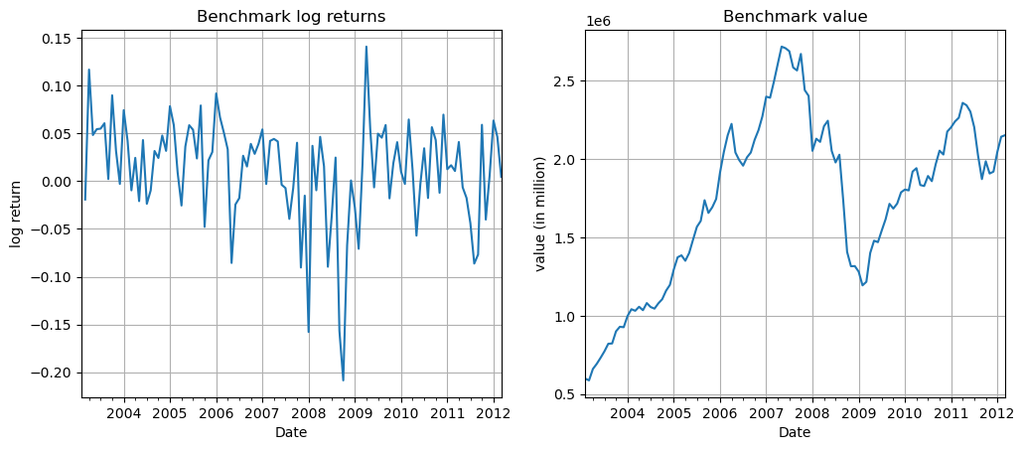

```python
plt.figure().set_figwidth(12)

plt.subplot(1,2,1)
benchmark.loc['log_returns'].plot(label = 'Benchmark')
plt.title("Benchmark log returns")
plt.ylabel("log return")
plt.grid()

plt.subplot(1,2,2)
benchmark.loc['value'].plot(label = 'Benchmark')
plt.title("Benchmark value")
plt.ylabel("value (in million)")
plt.grid()

plt.show()
```

# UniVariate Screening Models

## Function for UniVariate Screening

We are now going to build the function to calculate the univariate screening portfolios. The function takes in input:

1. data: the dataset containing the information of the factor for every stock.
2. holding: the holding period.
3. worst: False (default) if you want to get the stocks with the higher value of the factor.
4. wealth: initial investment. The default is 600000.
5. n_stocks: number of stocks to select in every holding period. The default is 15 stocks.
6. INtrans_cost: transaction costs. The default is 20 basis points.

The function return a portfolio dataset that has, for every month, the information about the value of the portfolio, its return, its cumulative return and its logarithmic returns.

```python
def uniPortfolio(data, holding, worst = False, wealth = 600000, n_stocks=15, INtrans_cost = 0.002):
    # Initiate dataset
    sub = pd.DataFrame(columns=time, index = stocks)
    # Set i = 1, we want to start at month 2, so that we can use the information of the factor at month 1
    i=1
    # Remove the transaction cost in the first iteration of wealth
    wealth = wealth * (1 - INtrans_cost)
    # Loop through i. i is going to represent the month in which the selected stocks are modified based on the factor
    while i < len(time):
        # If we are not in the first month, we have to compute the portfolio value in the new month before reallocation
        if i != 1:
            portfT = sub.iloc[:,i-1] * price_mul.iloc[:,i]
            # Overwrite the wealth as the portfolio total value
            wealth = portfT.sum()
        # Create a copy of the factor
        factor = data
        # From this new copy, select only the rows of the stocks for which we have the price_mul information
        if i+holding < len(time):
            factor = factor.loc[price_mul.iloc[:,range(i,i+ holding)].notnull().all(axis=1),:]
        else:
            factor = factor.loc[price_mul.iloc[:,i:].notnull().all(axis=1),:]
        # Select stocks based on factor
        sel_stocks = factor.sort_values(factor.columns[i-1], ascending=worst).index[:n_stocks]
        # Allocate wealth equally through the selected stocks
        sub.loc[sel_stocks, sub.columns[i]] = wealth/n_stocks
        # If we are not in the first month, than we have to compute the transaction costs
        if i != 1:
            # We compute the transaction costs based on the difference between the portfolio before and after reallocation
            trans_cost = abs(sub.iloc[:,i] - portfT).sum() * INtrans_cost
            # Remove the transaction cost from total wealth
            wealth = wealth - trans_cost
            # Overwrite allocation of wealth equally through the selected stocks
            sub.loc[sel_stocks, sub.columns[i]] = wealth/n_stocks
        # J is going to loop through the months in which there is no reallocation
        for j in range(1,holding):
            # Break the j loop if the months are finished
            if i + j > len(time)-1:
                break
            # Compute the value of all the stocks at time t as their value at time t-1 times theprice multiplicator at time t
            sub.iloc[:,i+j] = sub.iloc[:,i+j-1] * price_mul.iloc[:,i+j]
        # Increment i by the holding period before next iteration
        i += holding
    # Since we started from i=1, the first element of the subset is going to be 0, so we are going to remove it
    # Build output dataframe
    portf = pd.DataFrame(columns=time[1:])
    # Insert value information
    portf.loc['value'] = sub.sum()[1:]
    # Insert return information
    portf.loc['returns'] = (portf.loc['value'].astype('float') - portf.loc['value'].shift(1).astype('float'))/portf.loc['value'].shift(1).astype('float')
    portf.loc['cum_returns'] = (portf.loc['value'].astype('float') - portf.loc['value'][0])/portf.loc['value'][0]
    portf.loc['log_returns'] = np.log(portf.loc['value'].astype('float')) - np.log(portf.loc['value'].shift(1).astype('float'))
    return portf
```

## Building the necessary metrics

### Information Ratio

We are now going to build the Information Ratio metric in order to order the best univariate portfolios. In this way, we are going to understand which are the factors that lead to a better univariate screening portfolio, and use these in the sequantial and simultaneous models.

$$ IR = \frac{TE}{TEV} = \frac{E[R_p - R_b]}{\sqrt{var[R_p - R_b]}} $$

```python
def IR(port):
    num2 = benchmark.loc['log_returns']
    num1 = port.loc['log_returns']
    num = (num1 - num2).mean() * 12
    den = np.std(port.loc['log_returns'] - benchmark.loc['log_returns']) * np.sqrt(12)
    return num/den
```

### Sharpe Ratio

$$ S_a = \frac{E[R_p - R_f]}{\sqrt{var[R_p]}} $$

To represent the Risk Free asset we used the 13 weekes Treasury Bill.

```python
# Import the data from yahoo finance
import yfinance as yf
IRX = yf.download('^IRX','2002-12-31','2012-03-30', interval='1mo')
IRX = IRX['Close']
```

```
[*********************100%***********************]  1 of 1 completed
```

```python
IRX = pd.DataFrame(IRX).transpose()
IRX.index = ["value"]
IRX.columns = time
IRX
```

| Date | 2003-01-31 | 2003-02-28 | 2003-03-31 | 2003-04-30 | 2003-05-30 | 2003-06-30 | 2003-07-31 | 2003-08-29 | 2003-09-30 | 2003-10-31 | ... | 2011-06-30 | 2011-07-29 | 2011-08-31 | 2011-09-30 | 2011-10-31 | 2011-11-30 | 2011-12-30 | 2012-01-31 | 2012-02-29 | 2012-03-30 |
| --- | --- | --- | --- | --- | --- | --- | --- | --- | --- | --- | --- | --- | --- | --- | --- | --- | --- | --- | --- | --- | --- |
| value | 1.148 | 1.175 | 1.09 | 1.101 | 1.085 | 0.838 | 0.927 | 0.96 | 0.926 | 0.932 | ... | 0.015 | 0.09 | 0.015 | 0.01 | 0.005 | 0.015 | 0.005 | 0.055 | 0.075 | 0.065 |

1 rows × 111 columns

```python
IRX.loc['log_returns'] = np.log(IRX.loc['value'].astype('float')) - np.log(IRX.loc['value'].shift(1).astype('float'))
```

```python
def Sharpe(port):
    num2 = IRX.loc['log_returns'][1:]
    num1 = port.loc['log_returns']
    num = (num1 - num2).mean()
    den = np.std(port.loc['log_returns'])
    return num/den
```

### Sortino Ratio

$$ SO = \frac{E[R_p - R_f]}{DSR} $$

```python
def Sortino(port):
    num2 = IRX.loc['log_returns'][1:]
    num1 = port.loc['log_returns']
    num = (num1 - num2).mean()
    den = np.std(port.loc['log_returns', port.loc['log_returns'] < port.loc['log_returns'].mean()])
    return num/den
```

## Choosing the Parameters

In this section we are going to use the just computed metrics in order to decide the best parameters for the univariate screening function.

### Top-Bottom

First of all, we are going to understand, for each factor, which is the better performing portfolio, between the one built using the stocks with higher values of the factor and the one built using the stocks with lower values.

```python
# We are going to store the data in a list of two dictionary
comparison = [{},{}]
worst_list = [False, True]
# We are going to use the average of this four different holding periods
hold_list = [3,6,12,111]
# The first dictionary is going to contain the metrics relative to the portfolio that use the stocks
# with higher value of the factor. The second will use the lower.
for worst in range(len(worst_list)):
    # Loop through the factor
    for factor in tot_factors:
        # get the data of the factor
        sub = get_factor(factor)
        lst = []
        for i in range(4):
            hold = hold_list[i]
            port = uniPortfolio(sub, hold, n_stocks=100, worst = worst_list[worst], INtrans_cost = 0)
            lst.append(IR(port))
        # The resulting IR of the portfolio is computed as the average IR between the different holding periods
        comparison[worst][factor] = sum(lst) / len(lst)
```

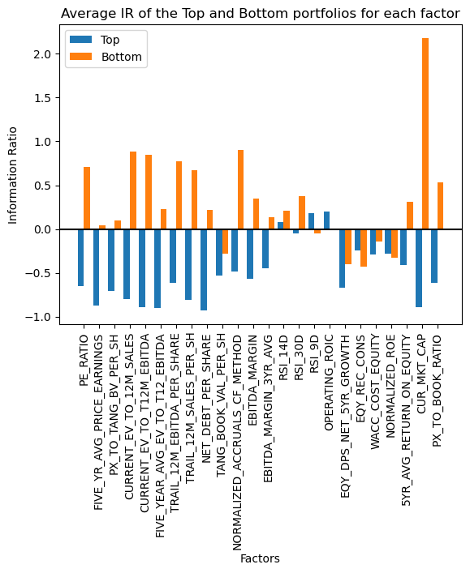

```python
X_axis = np.arange(len(comparison[0]))

plt.bar(X_axis -0.2, comparison[0].values(), 0.4, label = 'Top')
plt.bar(X_axis +0.2, comparison[1].values(), 0.4, label = 'Bottom')
plt.axhline(y = 0, color = 'black')


plt.xticks(X_axis, comparison[0].keys(), rotation = 90)
plt.xlabel("Factors")
plt.ylabel("Information Ratio")
plt.title("Average IR of the Top and Bottom portfolios for each factor")
plt.legend()
plt.show()
```

From the resulting plot we can see that the factor "current market cap" (using the assets with lower values) seems to achieve unusually high values of IR.

We now store this information in a new dictionary. The dictionary diz_factors will have, for each factor, the information relative to which kind of stocks have to be taken (top or bottom).

```python
diz_factors = {}
for el in range(len(comparison[0])):
    diz_factors[list(comparison[0].keys())[el]] = list(comparison[0].values())[el] < list(comparison[1].values())[el]
diz_factors
```

```
{'PE_RATIO': True,
 'FIVE_YR_AVG_PRICE_EARNINGS': True,
 'PX_TO_TANG_BV_PER_SH': True,
 'CURRENT_EV_TO_12M_SALES': True,
 'CURRENT_EV_TO_T12M_EBITDA': True,
 'FIVE_YEAR_AVG_EV_TO_T12_EBITDA': True,
 'TRAIL_12M_EBITDA_PER_SHARE': True,
 'TRAIL_12M_SALES_PER_SH': True,
 'NET_DEBT_PER_SHARE': True,
 'TANG_BOOK_VAL_PER_SH': True,
 'NORMALIZED_ACCRUALS_CF_METHOD': True,
 'EBITDA_MARGIN': True,
 'EBITDA_MARGIN_3YR_AVG': True,
 'RSI_14D': True,
 'RSI_30D': True,
 'RSI_9D': False,
 'OPERATING_ROIC': False,
 'EQY_DPS_NET_5YR_GROWTH': True,
 'EQY_REC_CONS': False,
 'WACC_COST_EQUITY': True,
 'NORMALIZED_ROE': False,
 '5YR_AVG_RETURN_ON_EQUITY': True,
 'CUR_MKT_CAP': True,
 'PX_TO_BOOK_RATIO': True}
```

### Holding Period

We are now going to choose the best holding period based on the average information ratio that its portfolios achieve.

```python
# The information is goint to be stored in a list of 4 dictionaries
hold_comparison = [{},{},{},{}]
# hold_list contains the holding periods we are going to compare
hold_list = [3,6,12,111]
# For each holding period and for each factor, compute the resulting IR of the portfolio
for i in range(4):
    hold = hold_list[i]
    for factor in diz_factors.keys():
        sub = get_factor(factor)
        port = uniPortfolio(sub, hold, n_stocks=15, worst = diz_factors[factor])
        hold_comparison[i][factor + "_" + str(hold)] = IR(port)
```

```python
lst_holdComp = []
# We store the value information in a list containing 4 lists
for i in range(4):
    lst_holdComp.append(list(hold_comparison[i].values()))
```

```python
import warnings
warnings.filterwarnings("ignore")
```

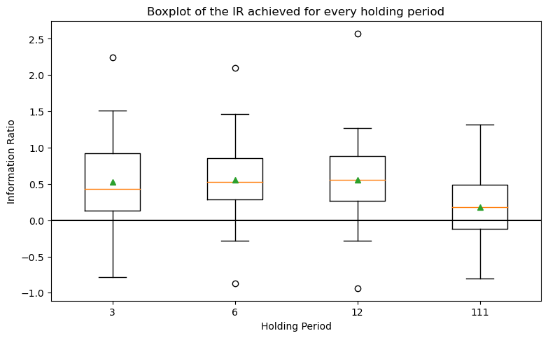

```python
fig = plt.figure(figsize =(7, 4))
# Creating axes instance
ax = fig.add_axes([0, 0, 1, 1])
ax.set_xticklabels(hold_list)
# Creating plot
bp = ax.boxplot(lst_holdComp, showmeans=True)
plt.axhline(y = 0, color = 'black')
plt.title("Boxplot of the IR achieved for every holding period")
plt.ylabel("Information Ratio")
plt.xlabel("Holding Period")
plt.show()
```

There are no statistically significant differences between the different holding period. Though, since the 12 month box has an higher mean, from now on we are going to consider this holding period. The outlier present in each of the first three holding period is the factor "current market cap".

## Univariate Screening Models Portfolios

We are now going to to build a portfolio for each factor and evaluate their metrics. In this way we are going to understand which are the factors that lead to a better univariate screening portfolio, and use these to build the following strategies.

```python
# Initialize an empty rank dataframe
rank = pd.DataFrame(columns = ['Information', 'Sharpe', 'Sortino'], index = list(diz_factors.keys()))
```

```python
# For each factor, build a portfolio and insert in the dataframe its resulting metrics
for factor in list(diz_factors.keys()):
    port = uniPortfolio(get_factor(factor), 12, n_stocks=15, worst=diz_factors[factor])
    rank.loc[factor, 'Information'] = IR(port)
    rank.loc[factor, 'Sharpe'] = Sharpe(port)
    rank.loc[factor, 'Sortino'] = Sortino(port)
```

```python
# Order the resulting portfolios by their resulting Information Ratio
rank = rank.sort_values(by='Information', ascending=False)
rank
```

|  | Information | Sharpe | Sortino |
| --- | --- | --- | --- |
| CUR_MKT_CAP | 2.572272 | 0.964028 | 1.774545 |
| PE_RATIO | 1.268581 | 0.775805 | 0.982374 |
| CURRENT_EV_TO_12M_SALES | 1.190999 | 0.694106 | 0.894214 |
| FIVE_YEAR_AVG_EV_TO_T12_EBITDA | 1.158677 | 0.756905 | 0.924165 |
| CURRENT_EV_TO_T12M_EBITDA | 1.107566 | 0.72325 | 0.874313 |
| PX_TO_BOOK_RATIO | 0.890569 | 0.567376 | 1.038024 |
| NORMALIZED_ACCRUALS_CF_METHOD | 0.887866 | 0.667879 | 1.106075 |
| 5YR_AVG_RETURN_ON_EQUITY | 0.852702 | 0.560658 | 0.861664 |
| TRAIL_12M_EBITDA_PER_SHARE | 0.735485 | 0.576269 | 1.07594 |
| EBITDA_MARGIN_3YR_AVG | 0.668972 | 0.583426 | 0.969576 |
| TRAIL_12M_SALES_PER_SH | 0.597328 | 0.588323 | 0.883077 |
| EBITDA_MARGIN | 0.578179 | 0.545594 | 1.023334 |
| RSI_9D | 0.532972 | 0.850518 | 1.085326 |
| PX_TO_TANG_BV_PER_SH | 0.488429 | 0.584849 | 0.87474 |
| RSI_30D | 0.453949 | 0.516281 | 0.768311 |
| EQY_DPS_NET_5YR_GROWTH | 0.388422 | 0.704911 | 1.085478 |
| FIVE_YR_AVG_PRICE_EARNINGS | 0.334923 | 0.6265 | 0.7239 |
| RSI_14D | 0.306011 | 0.482653 | 0.85147 |
| NET_DEBT_PER_SHARE | 0.142135 | 0.846456 | 1.029318 |
| WACC_COST_EQUITY | -0.047826 | 0.889192 | 1.347257 |
| OPERATING_ROIC | -0.212811 | 0.722881 | 0.958099 |
| EQY_REC_CONS | -0.225417 | 0.702182 | 0.759324 |
| NORMALIZED_ROE | -0.287531 | 0.62834 | 0.76751 |
| TANG_BOOK_VAL_PER_SH | -0.93403 | 0.45706 | 0.514472 |

### A deeper look into Current Market Cap

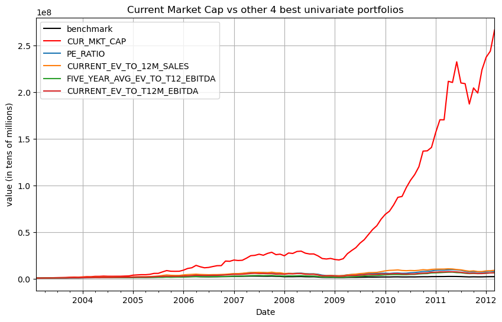

```python
plt.figure(figsize =(10, 6))

benchmark.loc['value'].plot(label = 'benchmark', color='black')
uniPortfolio(get_factor('CUR_MKT_CAP'), 12, worst=diz_factors['CUR_MKT_CAP']).loc['value'].plot(label = 'CUR_MKT_CAP', color='red')
uniPortfolio(get_factor('PE_RATIO'), 12, worst=diz_factors['PE_RATIO']).loc['value'].plot(label = 'PE_RATIO')
uniPortfolio(get_factor('CURRENT_EV_TO_12M_SALES'), 12, worst=diz_factors['CURRENT_EV_TO_12M_SALES']).loc['value'].plot(label = 'CURRENT_EV_TO_12M_SALES')
uniPortfolio(get_factor('FIVE_YEAR_AVG_EV_TO_T12_EBITDA'), 12, worst=diz_factors['FIVE_YEAR_AVG_EV_TO_T12_EBITDA']).loc['value'].plot(label = 'FIVE_YEAR_AVG_EV_TO_T12_EBITDA')
uniPortfolio(get_factor('CURRENT_EV_TO_T12M_EBITDA'), 12, worst=diz_factors['CURRENT_EV_TO_T12M_EBITDA']).loc['value'].plot(label = 'CURRENT_EV_TO_T12M_EBITDA')
plt.title("Current Market Cap vs other 4 best univariate portfolios")
plt.ylabel("value (in tens of millions)")
plt.grid()
plt.legend()
plt.show()
```

We now try to understand better this unusual returns of the portfolio built with the "Current Market Cap" factor. To do so, we build a portfolio with only one stock per year, and look for unusual returns.

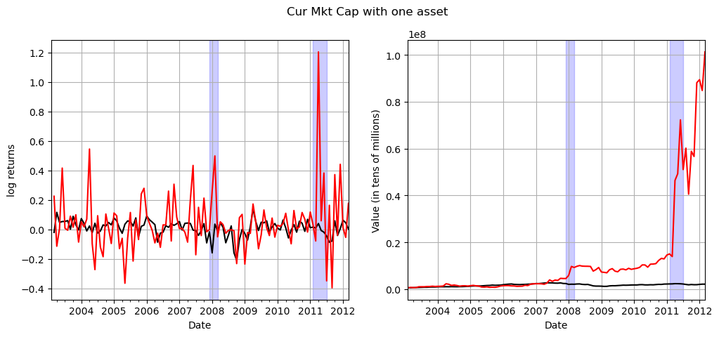

```python
plt.figure().set_figwidth(12)

plt.subplot(1,2,1)
benchmark.loc['log_returns'].plot(color = 'black', label='benchmark')
uniPortfolio(get_factor('CUR_MKT_CAP'), 12, worst=diz_factors['CUR_MKT_CAP'], n_stocks=1).loc['log_returns'].plot(color='red')
plt.axvspan(455, 458, color="blue", alpha=0.2)
plt.axvspan(493, 498, color="blue", alpha=0.2)
plt.ylabel("log returns")
plt.grid()

plt.subplot(1,2,2)
benchmark.loc['value'].plot(color = 'black', label='benchmark')
uniPortfolio(get_factor('CUR_MKT_CAP'), 12, worst=diz_factors['CUR_MKT_CAP'], n_stocks=1).loc['value'].plot(color='red', label='CurMktCap')
plt.grid()
plt.ylabel("Value (in tens of millions)")
plt.axvspan(455, 458, color="blue", alpha=0.2)
plt.axvspan(493, 498, color="blue", alpha=0.2)

plt.suptitle("Cur Mkt Cap with one asset")
plt.show()
```

The highest peaks in returns are achieved in the first months of 2008 and 2011

We are now going to check, for each year, which asset is bought, in order to understand which are the stocks that cause the problem.

```python
factor = get_factor('CUR_MKT_CAP')
year = 2003
for col in list(range(0,111,12)):
    non_nan_stocks = price.iloc[:,col:col+11][~price.iloc[:,col:col+11].isnull().any(axis=1)].index
    print(year, ": ", list(factor.loc[non_nan_stocks].iloc[:,col].sort_values(ascending=True).index)[0])
    year += 1
```

```
2003 :  WDI GR
2004 :  H4G GR
2005 :  ABE1 GR
2006 :  LCA1 GR
2007 :  MSU GR
2008 :  EUZ GR
2009 :  SIS GR
2010 :  SIS GR
2011 :  PRC FP
2012 :  FNM IM
```

The stocks causing the problems are those bought in year 2007 and 2011: 'MSU GR' and 'PRC FP'. We plot the prices below:

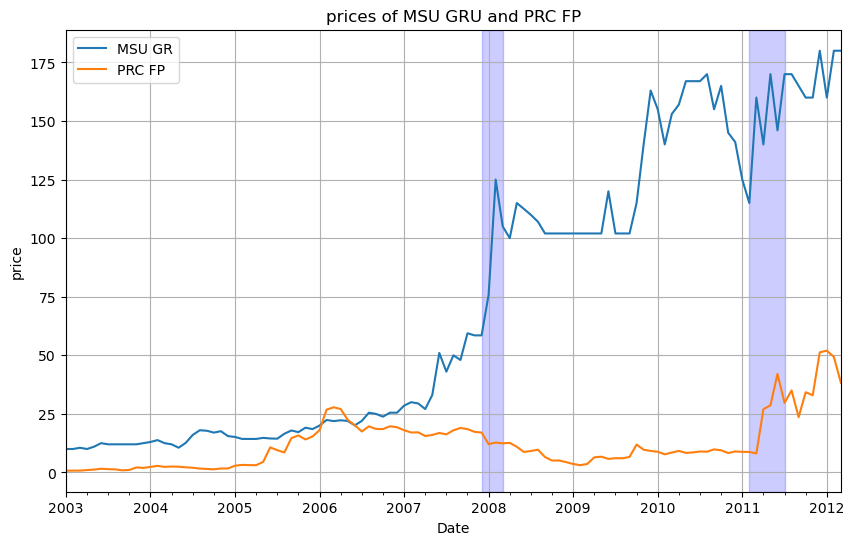

```python
plt.figure(figsize =(10, 6))

price.loc['MSU GR'].plot(label = 'MSU GR')
price.loc['PRC FP'].plot(label = 'PRC FP')
plt.axvspan(455, 458, color="blue", alpha=0.2)
plt.axvspan(493, 498, color="blue", alpha=0.2)
plt.ylabel("price")
plt.title("prices of MSU GRU and PRC FP")
plt.legend()
plt.grid()
plt.show()
```

**February 2008**: MSU GR starts from a price of 75 and gets to a price of 125 (+66%).  
**April 2011**: PRC FP starts from a price of 8.1 and gets to a price of 26.99 (+233%).

Considered the problems brought by the factor "Current Market Cap", we decided to remove the portfolios built with this factor, since they achieve unrealistic results. From now on, we will not consider Current Market Cap as a factor to build portfolios.

We are now going to plot the values of the 5 best univariate portfolios without considering the Current Market Cap.

```python
uni_pe = uniPortfolio(get_factor('PE_RATIO'), 12, worst=diz_factors['PE_RATIO'])
uni_evtosales = uniPortfolio(get_factor('CURRENT_EV_TO_12M_SALES'), 12, worst=diz_factors['CURRENT_EV_TO_12M_SALES'])
uni_avgEbitda = uniPortfolio(get_factor('FIVE_YEAR_AVG_EV_TO_T12_EBITDA'), 12, worst=diz_factors['FIVE_YEAR_AVG_EV_TO_T12_EBITDA'])
uni_currEbitda = uniPortfolio(get_factor('CURRENT_EV_TO_T12M_EBITDA'), 12, worst=diz_factors['CURRENT_EV_TO_T12M_EBITDA'])
uni_pxToBook = uniPortfolio(get_factor('PX_TO_BOOK_RATIO'), 12, worst=diz_factors['PX_TO_BOOK_RATIO'])
```

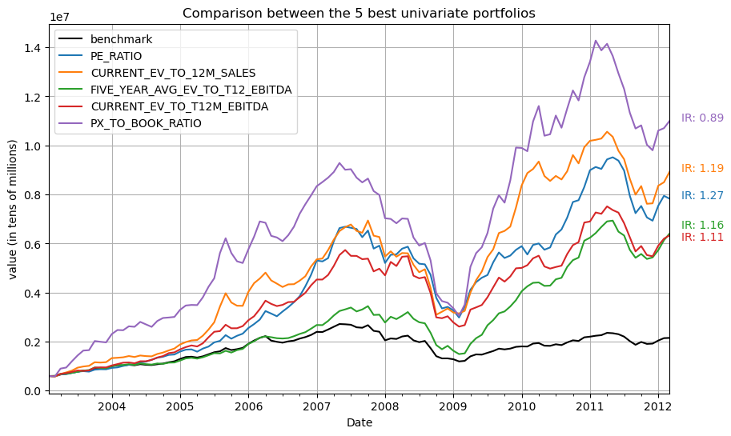

```python
plt.figure(figsize =(10, 6))

benchmark.loc['value'].plot(label = 'benchmark', color='black')
uni_pe.loc['value'].plot(label = 'PE_RATIO', color='C0')
uni_evtosales.loc['value'].plot(label = 'CURRENT_EV_TO_12M_SALES', color='C1')
uni_avgEbitda.loc['value'].plot(label = 'FIVE_YEAR_AVG_EV_TO_T12_EBITDA', color='C2')
uni_currEbitda.loc['value'].plot(label = 'CURRENT_EV_TO_T12M_EBITDA', color='C3')
uni_pxToBook.loc['value'].plot(label = 'PX_TO_BOOK_RATIO', color='C4')

plt.text(508, uni_pe.loc['value'][-1], 'IR: ' + str(round(IR(uni_pe),2)), color='C0')
plt.text(508, uni_evtosales.loc['value'][-1], 'IR: ' + str(round(IR(uni_evtosales),2)), color='C1')
plt.text(508, uni_avgEbitda.loc['value'][-1] +200000, 'IR: ' + str(round(IR(uni_avgEbitda),2)), color='C2')
plt.text(508, uni_currEbitda.loc['value'][-1] -200000, 'IR: ' + str(round(IR(uni_currEbitda),2)), color='C3')
plt.text(508, uni_pxToBook.loc['value'][-1], 'IR: ' + str(round(IR(uni_pxToBook),2)), color='C4')

plt.title("Comparison between the 5 best univariate portfolios")
plt.ylabel("value (in tens of millions)")
plt.legend()
plt.grid()
plt.show()
```

# Sequential Screening

We are now going to write a function to build a sequential portfolio. The screening portfolios are going to be built using three factors. On each of the first two screening phases, the best 30% stocks are selected by the function. In the last screening phase the function selects the best 15 stocks. The holding period is still set to 12.

```python
def seqPortfolio(data, holding, worst = None, wealth = 600000):
    # build the "worst" list
    if worst is None:
        worst = []
        for factor in range(len(data)):
            worst.append(diz_factors[data[factor]])
    # Initiate dataset
    sub = pd.DataFrame(columns=time, index = stocks)
    # Set i = 1, we want to start at month 2, so that we can use the information of the factor at month 1
    i=1
    # Remove the transaction cost in the first iteration of wealth
    wealth = wealth * 0.998
    # Loop through i. i is going to represent the month in which the selected stocks are modified based on the factor
    while i < len(time):
        # If we are not in the first month, we have to compute the portfolio value in the new month before reallocation
        if i != 1:
            portfT = sub.iloc[:,i-1] * price_mul.iloc[:,i]
            # Overwrite the wealth as the portfolio total value
            wealth = portfT.sum()
        # Create a copy of the factors
        factor1 = get_factor(data[0])
        factor2 = get_factor(data[1])
        factor3 = get_factor(data[2])
        # From this new copy, select only the rows of the stocks for which we have the price_mul information
        factor1 = factor1.loc[price_mul.iloc[:,i].notnull(),:]
        # Select stocks based on factor
        sel_stocks = factor1.sort_values(factor1.columns[i-1], ascending=worst[0]).index[:round(len(factor1)*0.3)]
        factor2 = factor2.loc[sel_stocks]
        sel_stocks = factor2.sort_values(factor2.columns[i-1], ascending=worst[1]).index[:round(len(factor2)*0.3)]
        factor3 = factor3.loc[sel_stocks]
        sel_stocks = factor3.sort_values(factor3.columns[i-1], ascending=worst[2]).index[:15]
        # Allocate wealth equally through the selected stocks
        sub.loc[sel_stocks, sub.columns[i]] = wealth/len(sel_stocks)
        # If we are not in the first month, than we have to compute the transaction costs
        if i != 1:
            # We compute the transaction costs based on the difference between the portfolio before and after reallocation
            trans_cost = abs(sub.iloc[:,i] - portfT).sum() * 0.002
            # Remove the transaction cost from total wealth
            wealth = wealth - trans_cost
            # Overwrite allocation of wealth equally through the selected stocks
            sub.loc[sel_stocks, sub.columns[i]] = wealth/len(sel_stocks)
        # J is going to loop through the months in which there is no reallocation
        for j in range(1,holding):
            # Break the j loop if the months are finished
            if i + j > len(time)-1:
                break
            # Compute the value of all the stocks at time t as their value at time t-1 times theprice multiplicator at time t
            sub.iloc[:,i+j] = sub.iloc[:,i+j-1] * price_mul.iloc[:,i+j]
        # Increment i by the holding period before next iteration
        i += holding
    # Since we started from i=1, the first element of the subset is going to be 0, so we are going to remove it
    # Build output dataframe
    portf = pd.DataFrame(columns=time[1:])
    # Insert value information
    portf.loc['value'] = sub.sum()[1:]
    # Insert return information
    portf.loc['returns'] = (portf.loc['value'].astype('float') - portf.loc['value'].shift(1).astype('float'))/portf.loc['value'].shift(1).astype('float')
    portf.loc['cum_returns'] = (portf.loc['value'].astype('float') - portf.loc['value'][0])/portf.loc['value'][0]
    portf.loc['log_returns'] = np.log(portf.loc['value'].astype('float')) - np.log(portf.loc['value'].shift(1).astype('float'))
    return portf
```

The first portfolio is created by 3 sequential screening over the three best performing factors from the univariate strategy.

```python
portf_seq_top3 = seqPortfolio(['PE_RATIO','CURRENT_EV_TO_12M_SALES','FIVE_YEAR_AVG_EV_TO_T12_EBITDA'], 12)
portf_seq_top3
```

| Date | 2003-02-28 | 2003-03-31 | 2003-04-30 | 2003-05-30 | 2003-06-30 | 2003-07-31 | 2003-08-29 | 2003-09-30 | 2003-10-31 | 2003-11-28 | ... | 2011-06-30 | 2011-07-29 | 2011-08-31 | 2011-09-30 | 2011-10-31 | 2011-11-30 | 2011-12-30 | 2012-01-31 | 2012-02-29 | 2012-03-30 |
| --- | --- | --- | --- | --- | --- | --- | --- | --- | --- | --- | --- | --- | --- | --- | --- | --- | --- | --- | --- | --- | --- |
| value | 598800.0 | 604790.262009 | 661637.714469 | 713975.581809 | 737923.832265 | 787567.109524 | 843784.158616 | 846232.486133 | 956529.571639 | 962561.761368 | ... | 6194101.956307 | 6030898.120106 | 5520898.077803 | 5091280.32388 | 5350267.86917 | 4957809.266168 | 4945702.428624 | 5252104.850658 | 5554369.514622 | 5807879.492871 |
| returns | NaN | 0.010004 | 0.093995 | 0.079104 | 0.033542 | 0.067274 | 0.071381 | 0.002902 | 0.130339 | 0.006306 | ... | -0.022299 | -0.026348 | -0.084565 | -0.077817 | 0.050869 | -0.073353 | -0.002442 | 0.061953 | 0.057551 | 0.045642 |
| cum_returns | 0.0 | 0.010004 | 0.104939 | 0.192344 | 0.232338 | 0.315242 | 0.409125 | 0.413214 | 0.597411 | 0.607485 | ... | 9.344192 | 9.07164 | 8.219937 | 7.502472 | 7.934983 | 7.279575 | 7.259356 | 7.77105 | 8.275834 | 8.699198 |
| log_returns | NaN | 0.009954 | 0.089836 | 0.076131 | 0.032992 | 0.065108 | 0.068948 | 0.002897 | 0.122518 | 0.006287 | ... | -0.022552 | -0.026702 | -0.088355 | -0.081011 | 0.049617 | -0.076183 | -0.002445 | 0.06011 | 0.055956 | 0.044631 |

4 rows × 110 columns

The second portfolio is created in the same way as the first, but the three screening are inverted. Therefore, the first screening is done with the third best factor, the second with the second best factor, and the third with the first best univariate factor.

```python
portf_seq_top3_inv = seqPortfolio(['FIVE_YEAR_AVG_EV_TO_T12_EBITDA','CURRENT_EV_TO_12M_SALES','PE_RATIO'], 12)
portf_seq_top3
```

| Date | 2003-02-28 | 2003-03-31 | 2003-04-30 | 2003-05-30 | 2003-06-30 | 2003-07-31 | 2003-08-29 | 2003-09-30 | 2003-10-31 | 2003-11-28 | ... | 2011-06-30 | 2011-07-29 | 2011-08-31 | 2011-09-30 | 2011-10-31 | 2011-11-30 | 2011-12-30 | 2012-01-31 | 2012-02-29 | 2012-03-30 |
| --- | --- | --- | --- | --- | --- | --- | --- | --- | --- | --- | --- | --- | --- | --- | --- | --- | --- | --- | --- | --- | --- |
| value | 598800.0 | 604790.262009 | 661637.714469 | 713975.581809 | 737923.832265 | 787567.109524 | 843784.158616 | 846232.486133 | 956529.571639 | 962561.761368 | ... | 6194101.956307 | 6030898.120106 | 5520898.077803 | 5091280.32388 | 5350267.86917 | 4957809.266168 | 4945702.428624 | 5252104.850658 | 5554369.514622 | 5807879.492871 |
| returns | NaN | 0.010004 | 0.093995 | 0.079104 | 0.033542 | 0.067274 | 0.071381 | 0.002902 | 0.130339 | 0.006306 | ... | -0.022299 | -0.026348 | -0.084565 | -0.077817 | 0.050869 | -0.073353 | -0.002442 | 0.061953 | 0.057551 | 0.045642 |
| cum_returns | 0.0 | 0.010004 | 0.104939 | 0.192344 | 0.232338 | 0.315242 | 0.409125 | 0.413214 | 0.597411 | 0.607485 | ... | 9.344192 | 9.07164 | 8.219937 | 7.502472 | 7.934983 | 7.279575 | 7.259356 | 7.77105 | 8.275834 | 8.699198 |
| log_returns | NaN | 0.009954 | 0.089836 | 0.076131 | 0.032992 | 0.065108 | 0.068948 | 0.002897 | 0.122518 | 0.006287 | ... | -0.022552 | -0.026702 | -0.088355 | -0.081011 | 0.049617 | -0.076183 | -0.002445 | 0.06011 | 0.055956 | 0.044631 |

4 rows × 110 columns

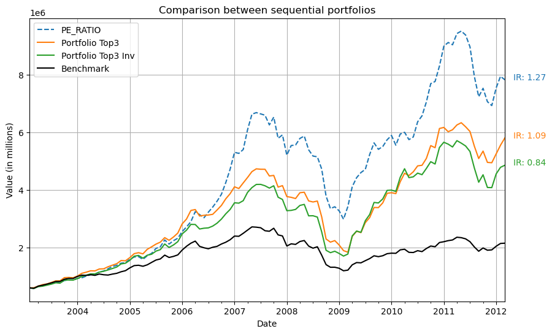

```python
plt.figure(figsize =(10, 6))
uni_pe.loc['value'].plot(label = 'PE_RATIO', color='C0', linestyle = 'dashed')
portf_seq_top3.loc['value'].plot(label = 'Portfolio Top3', color='C1')
portf_seq_top3_inv.loc['value'].plot(label = 'Portfolio Top3 Inv', color='C2')
benchmark.loc['value'].plot(label = 'Benchmark', color = 'black')
plt.grid()
plt.title("Comparison between sequential portfolios")
plt.ylabel("Value (in millions)")
plt.text(508, uni_pe.loc['value'][-1], 'IR: ' + str(round(IR(uni_pe),2)), color='C0')
plt.text(508, portf_seq_top3.loc['value'][-1], 'IR: ' + str(round(IR(portf_seq_top3),2)), color='C1')
plt.text(508, portf_seq_top3_inv.loc['value'][-1], 'IR: ' + str(round(IR(portf_seq_top3_inv),2)), color='C2')
plt.legend()
plt.show()
```

```python
# Initialize an empty rank dataframe
rank_seq = pd.DataFrame(columns = ['Information', 'Sharpe', 'Sortino'],
                    index = ['portf_seq_top3', 'portf_seq_top3_inv'])
```

```python
# For each portfolio insert in the dataframe its resulting metrics
port_list = [portf_seq_top3, portf_seq_top3_inv]
for i in range(2):
    rank_seq.iloc[i]['Information'] = IR(port_list[i])
    rank_seq.iloc[i]['Sharpe'] = Sharpe(port_list[i])
    rank_seq.iloc[i]['Sortino'] = Sortino(port_list[i])
```

```python
# Order the resulting portfolios by their resulting Information Ratio
rank_seq
```

|  | Information | Sharpe | Sortino |
| --- | --- | --- | --- |
| portf_seq_top3 | 1.092642 | 0.729568 | 0.895137 |
| portf_seq_top3_inv | 0.841387 | 0.657162 | 0.803223 |

The portfolio built with the top 3 factors is the one achieving higher performances on all the available metrics. Though, none of the two sequential portfolio seem to achieve as high as the best univariate portfolio (built using the pe ratio).

# Simultaneous Screening

We are now going to write a function to build a simultaneous portfolio.

```python
def simPortfolio(data, holding, wealth = 600000, n_stocks=15):
    # Initialize worst list
    worst = []
    for factor in range(len(data)):
        worst.append(diz_factors[data[factor]])
    # Initiate dataset
    sub = pd.DataFrame(columns=time, index = stocks)
    # Set i = 1, we want to start at month 2, so that we can use the information of the factor at month 1
    i=1
    # Remove the transaction cost in the first iteration of wealth
    wealth = wealth * 0.998
    # Loop through i. i is going to represent the month in which the selected stocks are modified based on the factor
    while i < len(time):
        # If we are not in the first month, we have to compute the portfolio value in the new month before reallocation
        if i != 1:
            portfT = sub.iloc[:,i-1] * price_mul.iloc[:,i]
            # Overwrite the wealth as the portfolio total value
            wealth = portfT.sum()
        # Create a copy of the factors
        fac = []
        for el in range(len(data)):
            fac.append(get_factor(data[el]).loc[price_mul.iloc[:,i].notnull(),:])
        # Initialize a df that is going to contain the z scores
        sub_factor = pd.DataFrame(columns=range(len(data)+1), index = fac[0].index)
        for el in range(len(data)):
            # Scale every column
            new_col = scale(fac[el].iloc[:,i-1])
            # If we have to get the bottom value stocks, we multiplicate the corresponding column for -1
            if worst[el]:
                new_col = new_col * -1
            sub_factor[el] = new_col
        # The last column of the df contains the average of the z score
        sub_factor.iloc[:,-1] = sub_factor.mean(axis=1)
        # We select the best stocks based on this last column
        sel_stocks = sub_factor.sort_values(sub_factor.columns[-1], ascending=False).index[:n_stocks]
        # Allocate wealth equally through the selected stocks
        sub.loc[sel_stocks, sub.columns[i]] = wealth/len(sel_stocks)
        # If we are not in the first month, than we have to compute the transaction costs
        if i != 1:
            # We compute the transaction costs based on the difference between the portfolio before and after reallocation
            trans_cost = abs(sub.iloc[:,i] - portfT).sum() * 0.002
            # Remove the transaction cost from total wealth
            wealth = wealth - trans_cost
            # Overwrite allocation of wealth equally through the selected stocks
            sub.loc[sel_stocks, sub.columns[i]] = wealth/len(sel_stocks)
        # J is going to loop through the months in which there is no reallocation
        for j in range(1,holding):
            # Break the j loop if the months are finished
            if i + j > len(time)-1:
                break
            # Compute the value of all the stocks at time t as their value at time t-1 times theprice multiplicator at time t
            sub.iloc[:,i+j] = sub.iloc[:,i+j-1] * price_mul.iloc[:,i+j]
        # Increment i by the holding period before next iteration
        i += holding
    # Since we started from i=1, the first element of the subset is going to be 0, so we are going to remove it
    # Build output dataframe
    portf = pd.DataFrame(columns=time[1:])
    # Insert value information
    portf.loc['value'] = sub.sum()[1:]
    # Insert return information
    portf.loc['returns'] = (portf.loc['value'].astype('float') - portf.loc['value'].shift(1).astype('float'))/portf.loc['value'].shift(1).astype('float')
    portf.loc['cum_returns'] = (portf.loc['value'].astype('float') - portf.loc['value'][0])/portf.loc['value'][0]
    portf.loc['log_returns'] = np.log(portf.loc['value'].astype('float')) - np.log(portf.loc['value'].shift(1).astype('float'))
    return portf
```

The first portfolio is built using the 3 factors corresponding to the 3 best univariate portfolios.

```python
portf_sim_top3 = simPortfolio(['PE_RATIO','CURRENT_EV_TO_12M_SALES','FIVE_YEAR_AVG_EV_TO_T12_EBITDA'], 12)
portf_sim_top3
```

| Date | 2003-02-28 | 2003-03-31 | 2003-04-30 | 2003-05-30 | 2003-06-30 | 2003-07-31 | 2003-08-29 | 2003-09-30 | 2003-10-31 | 2003-11-28 | ... | 2011-06-30 | 2011-07-29 | 2011-08-31 | 2011-09-30 | 2011-10-31 | 2011-11-30 | 2011-12-30 | 2012-01-31 | 2012-02-29 | 2012-03-30 |
| --- | --- | --- | --- | --- | --- | --- | --- | --- | --- | --- | --- | --- | --- | --- | --- | --- | --- | --- | --- | --- | --- |
| value | 598800.0 | 617508.808839 | 706541.893857 | 710354.620817 | 756534.472363 | 848790.42887 | 884299.704912 | 880158.792739 | 968782.255865 | 1016708.20419 | ... | 3959043.090802 | 3900238.491907 | 3510312.977577 | 3278671.988075 | 3390207.807767 | 3244822.484614 | 3303015.975812 | 3384307.127542 | 3671914.783331 | 3826073.925732 |
| returns | NaN | 0.031244 | 0.144181 | 0.005396 | 0.06501 | 0.121945 | 0.041835 | -0.004683 | 0.10069 | 0.04947 | ... | -0.063493 | -0.014853 | -0.099975 | -0.065989 | 0.034019 | -0.042884 | 0.017934 | 0.024611 | 0.084983 | 0.041983 |
| cum_returns | 0.0 | 0.031244 | 0.17993 | 0.186297 | 0.263418 | 0.417486 | 0.476786 | 0.469871 | 0.617873 | 0.697909 | ... | 5.611628 | 5.513424 | 4.862246 | 4.475404 | 4.66167 | 4.418875 | 4.516059 | 4.651816 | 5.132122 | 5.389569 |
| log_returns | NaN | 0.030766 | 0.134689 | 0.005382 | 0.062984 | 0.115064 | 0.040984 | -0.004694 | 0.095938 | 0.048286 | ... | -0.065598 | -0.014965 | -0.105333 | -0.068267 | 0.033453 | -0.043831 | 0.017775 | 0.024313 | 0.081564 | 0.041126 |

4 rows × 110 columns

The last portfolio is built using the 6 factors corresponding to the best 6 best univariate portfolios.

```python
portf_sim_top6 = simPortfolio(['PE_RATIO','CURRENT_EV_TO_12M_SALES','FIVE_YEAR_AVG_EV_TO_T12_EBITDA',
                              'CURRENT_EV_TO_T12M_EBITDA', 'PX_TO_BOOK_RATIO', 'NORMALIZED_ACCRUALS_CF_METHOD'], 12)
portf_sim_top6
```

| Date | 2003-02-28 | 2003-03-31 | 2003-04-30 | 2003-05-30 | 2003-06-30 | 2003-07-31 | 2003-08-29 | 2003-09-30 | 2003-10-31 | 2003-11-28 | ... | 2011-06-30 | 2011-07-29 | 2011-08-31 | 2011-09-30 | 2011-10-31 | 2011-11-30 | 2011-12-30 | 2012-01-31 | 2012-02-29 | 2012-03-30 |
| --- | --- | --- | --- | --- | --- | --- | --- | --- | --- | --- | --- | --- | --- | --- | --- | --- | --- | --- | --- | --- | --- |
| value | 598800.0 | 596411.815668 | 686730.452715 | 695754.610035 | 774412.47938 | 862734.482066 | 1039841.880571 | 999939.47258 | 1186294.118391 | 1175397.848545 | ... | 13343887.837536 | 12947041.015565 | 11874416.913412 | 11222909.600969 | 11364509.042881 | 10892290.292138 | 11110460.672337 | 11517024.695496 | 12198350.325132 | 12524348.917149 |
| returns | NaN | -0.003988 | 0.151437 | 0.013141 | 0.113054 | 0.11405 | 0.205286 | -0.038374 | 0.186366 | -0.009185 | ... | -0.056139 | -0.02974 | -0.082847 | -0.054866 | 0.012617 | -0.041552 | 0.02003 | 0.036593 | 0.059158 | 0.026725 |
| cum_returns | 0.0 | -0.003988 | 0.146844 | 0.161915 | 0.293274 | 0.440772 | 0.736543 | 0.669906 | 0.981119 | 0.962922 | ... | 21.284382 | 20.621645 | 18.830356 | 17.742334 | 17.978806 | 17.190198 | 17.554544 | 18.233508 | 19.371327 | 19.915746 |
| log_returns | NaN | -0.003996 | 0.14101 | 0.013055 | 0.107108 | 0.108002 | 0.186717 | -0.039129 | 0.170895 | -0.009228 | ... | -0.057776 | -0.030191 | -0.086481 | -0.056429 | 0.012538 | -0.04244 | 0.019832 | 0.035939 | 0.057474 | 0.026374 |

4 rows × 110 columns

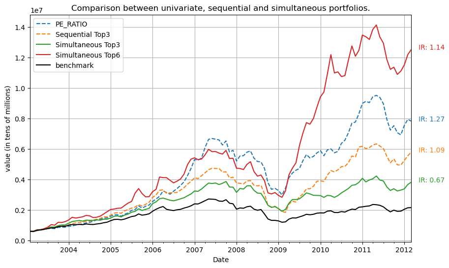

```python
plt.figure(figsize =(10, 6))

uni_pe.loc['value'].plot(label = 'PE_RATIO', color='C0', linestyle = 'dashed')
portf_seq_top3.loc['value'].plot(label = 'Sequential Top3', color='C1', linestyle = 'dashed')
portf_sim_top3.loc['value'].plot(label = "Simultaneous Top3", color='C2')
portf_sim_top6.loc['value'].plot(label = 'Simultaneous Top6', color='C3')
benchmark.loc['value'].plot(label = "benchmark", color='black')

plt.grid()
plt.ylabel("Value (in millions)")
plt.text(508, uni_pe.loc['value'][-1], 'IR: ' + str(round(IR(uni_pe),2)), color='C0')
plt.text(508, portf_seq_top3.loc['value'][-1], 'IR: ' + str(round(IR(portf_seq_top3),2)), color='C1')
plt.text(508, portf_sim_top3.loc['value'][-1], 'IR: ' + str(round(IR(portf_sim_top3),2)), color='C2')
plt.text(508, portf_sim_top6.loc['value'][-1], 'IR: ' + str(round(IR(portf_sim_top6),2)), color='C3')

plt.title("Comparison between univariate, sequential and simultaneous portfolios.")
plt.ylabel("value (in tens of millions)")
plt.legend()
plt.show()
```

While the simultaneous top 3 portfolio didn't achieve great returns, the simultaneous top 6 portfolio outperformed all the other strategies. The higher performances are linked with more risk, and this is reflected in the Information Ratio, that is still lower than the univariate portfolio built with the PE ratio.

# Accounting for correlation between factors

## Correlation Between Univariate Portfolios

```python
rank.sort_values(by='Information', ascending=False).iloc[1]
```

```
Information    1.268581
Sharpe         0.775805
Sortino        0.982374
Name: PE_RATIO, dtype: object
```

```python
data_univariate = []
for factor in tot_factors:
    data_univariate.append(list(uniPortfolio(get_factor(factor),12).loc['value']))
```

```python
df_corr1 = np.corrcoef(data_univariate)
```

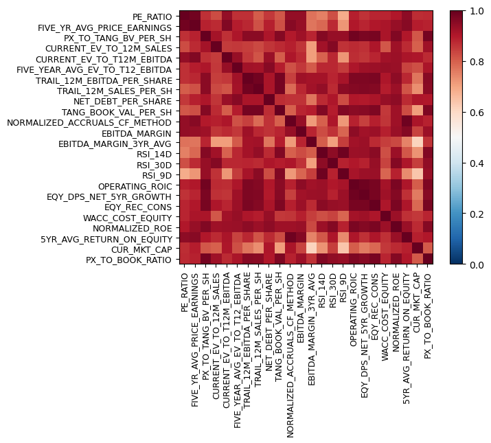

```python
plt.imshow(df_corr1, cmap = 'RdBu_r', interpolation='nearest', vmax=1, vmin=0)
# Add legend
plt.colorbar()
labels = tot_factors
# Create list with tick_mark positions
tick_marks = [i for i in range(len(tot_factors))]
# Add the tickmarks at the designated position, using the labels of the dataframe
plt.xticks(tick_marks, labels, rotation='vertical', fontsize=9)
plt.yticks(tick_marks, labels, fontsize=9)
plt.show()
```

```python
df_corr1 = pd.DataFrame(df_corr1, columns = tot_factors, index = tot_factors)
```

```python
uncorr_factors = df_corr1.loc[:,'PE_RATIO'][df_corr1.loc[:,'PE_RATIO'] < 0.85]
uncorr_factors
```

```
CURRENT_EV_TO_12M_SALES    0.827129
TRAIL_12M_SALES_PER_SH     0.801906
TANG_BOOK_VAL_PER_SH       0.811133
EBITDA_MARGIN_3YR_AVG      0.771817
RSI_14D                    0.750167
RSI_30D                    0.823930
RSI_9D                     0.687097
Name: PE_RATIO, dtype: float64
```

```python
rank.loc[uncorr_factors.index].sort_values(by='Information', ascending=False)
```

|  | Information | Sharpe | Sortino |
| --- | --- | --- | --- |
| CURRENT_EV_TO_12M_SALES | 1.190999 | 0.694106 | 0.894214 |
| EBITDA_MARGIN_3YR_AVG | 0.668972 | 0.583426 | 0.969576 |
| TRAIL_12M_SALES_PER_SH | 0.597328 | 0.588323 | 0.883077 |
| RSI_9D | 0.532972 | 0.850518 | 1.085326 |
| RSI_30D | 0.453949 | 0.516281 | 0.768311 |
| RSI_14D | 0.306011 | 0.482653 | 0.85147 |
| TANG_BOOK_VAL_PER_SH | -0.93403 | 0.45706 | 0.514472 |

```python
uncorr_factors = df_corr1.loc[uncorr_factors.index].loc[:,'CURRENT_EV_TO_12M_SALES'][df_corr1.loc[:,'CURRENT_EV_TO_12M_SALES'] < 0.85]
uncorr_factors
```

```
TRAIL_12M_SALES_PER_SH    0.829442
EBITDA_MARGIN_3YR_AVG     0.708955
Name: CURRENT_EV_TO_12M_SALES, dtype: float64
```

```python
rank.loc[uncorr_factors.index].sort_values(by='Information', ascending=False)
```

|  | Information | Sharpe | Sortino |
| --- | --- | --- | --- |
| EBITDA_MARGIN_3YR_AVG | 0.668972 | 0.583426 | 0.969576 |
| TRAIL_12M_SALES_PER_SH | 0.597328 | 0.588323 | 0.883077 |

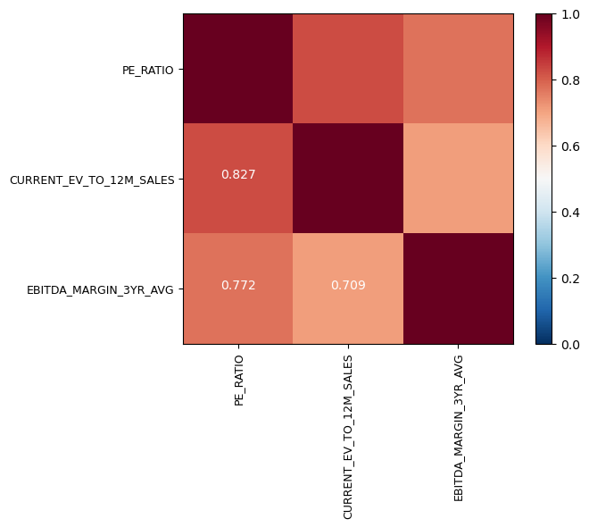

```python
plt.imshow(df_corr1.loc[['PE_RATIO', 'CURRENT_EV_TO_12M_SALES', 'EBITDA_MARGIN_3YR_AVG'], ['PE_RATIO', 'CURRENT_EV_TO_12M_SALES', 'EBITDA_MARGIN_3YR_AVG']],
           cmap = 'RdBu_r', interpolation='nearest', vmax=1, vmin=0)
# Add legend
plt.colorbar()
labels = ['PE_RATIO', 'CURRENT_EV_TO_12M_SALES', 'EBITDA_MARGIN_3YR_AVG']
# Create list with tick_mark positions
tick_marks = [i for i in range(3)]
# Add the tickmarks at the designated position, using the labels of the dataframe
plt.xticks(tick_marks, labels, rotation='vertical', fontsize=9)
plt.yticks(tick_marks, labels, fontsize=9)
plt.text(0, 1, '0.827', horizontalalignment="center", color='white')
plt.text(0, 2, '0.772', horizontalalignment="center", color='white')
plt.text(1, 2, '0.709', horizontalalignment="center", color='white')
plt.show()
```

```python
portf_uncorr_seq1 = seqPortfolio(['PE_RATIO', 'CURRENT_EV_TO_12M_SALES', 'EBITDA_MARGIN_3YR_AVG'], 12)
portf_uncorr_seq_inv1 = seqPortfolio(['EBITDA_MARGIN_3YR_AVG','CURRENT_EV_TO_12M_SALES', 'PE_RATIO'], 12)
portf_uncorr_sim1 = simPortfolio(['PE_RATIO', 'CURRENT_EV_TO_12M_SALES', 'EBITDA_MARGIN_3YR_AVG'], 12)
```

## Correlation Between Factors

In this second strategy, instead of building the portfolios evaluating the correlation between the univariate portfolios built with each factor, we compute the correlation between each factor itself.

```python
corr_list = []
# For every stock, build a correlation matrix of the time series of its factor, and append it to the corr_list
for stock in stocks:
    ind = df.index.get_loc(stock + ' Equity')
    corr_list.append(df.iloc[ind+2:ind+42].transpose().astype('float64').corr())
# Calculate the df_corr2 as the average correlation matrix between all the correlation matrixes in the list
df_corr2 = pd.concat(corr_list)
df_corr2 = df_corr2.groupby(level=0).mean()
df_corr2 = df_corr2[list(df_corr2.index)]
df_corr2 = df_corr2.loc[tot_factors,tot_factors]
```

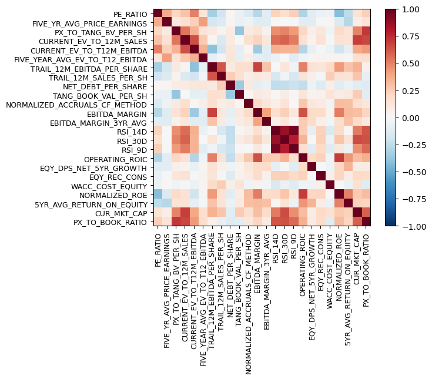

```python
plt.imshow(df_corr2, cmap = 'RdBu_r', interpolation='nearest', vmax=1, vmin=-1)
# Add legend
plt.colorbar()
labels = tot_factors
# Create list with tick_mark positions
tick_marks = [i for i in range(len(tot_factors))]
# Add the tickmarks at the designated position, using the labels of the dataframe
plt.xticks(tick_marks, labels, rotation='vertical', fontsize=9)
plt.yticks(tick_marks, labels, fontsize=9)
plt.show()
```

```python
uncorr_factors = df_corr2.loc[:,'PE_RATIO'][df_corr2.loc[:,'PE_RATIO'] < 0.2]
uncorr_factors
```

```
0
FIVE_YEAR_AVG_EV_TO_T12_EBITDA    0.122001
TRAIL_12M_EBITDA_PER_SHARE       -0.331919
TRAIL_12M_SALES_PER_SH           -0.190967
NET_DEBT_PER_SHARE                0.020325
TANG_BOOK_VAL_PER_SH             -0.069882
NORMALIZED_ACCRUALS_CF_METHOD    -0.137099
EBITDA_MARGIN                    -0.281752
EBITDA_MARGIN_3YR_AVG            -0.105860
RSI_30D                           0.162066
OPERATING_ROIC                   -0.299678
EQY_DPS_NET_5YR_GROWTH           -0.110507
EQY_REC_CONS                     -0.067301
WACC_COST_EQUITY                 -0.051332
NORMALIZED_ROE                   -0.428298
5YR_AVG_RETURN_ON_EQUITY         -0.251224
CUR_MKT_CAP                       0.138047
Name: PE_RATIO, dtype: float64
```

```python
rank.loc[uncorr_factors.index].sort_values(by='Information', ascending=False)
```

| 0 | Information | Sharpe | Sortino |
| --- | --- | --- | --- |
| CUR_MKT_CAP | 2.572272 | 0.964028 | 1.774545 |
| FIVE_YEAR_AVG_EV_TO_T12_EBITDA | 1.158677 | 0.756905 | 0.924165 |
| NORMALIZED_ACCRUALS_CF_METHOD | 0.887866 | 0.667879 | 1.106075 |
| 5YR_AVG_RETURN_ON_EQUITY | 0.852702 | 0.560658 | 0.861664 |
| TRAIL_12M_EBITDA_PER_SHARE | 0.735485 | 0.576269 | 1.07594 |
| EBITDA_MARGIN_3YR_AVG | 0.668972 | 0.583426 | 0.969576 |
| TRAIL_12M_SALES_PER_SH | 0.597328 | 0.588323 | 0.883077 |
| EBITDA_MARGIN | 0.578179 | 0.545594 | 1.023334 |
| RSI_30D | 0.453949 | 0.516281 | 0.768311 |
| EQY_DPS_NET_5YR_GROWTH | 0.388422 | 0.704911 | 1.085478 |
| NET_DEBT_PER_SHARE | 0.142135 | 0.846456 | 1.029318 |
| WACC_COST_EQUITY | -0.047826 | 0.889192 | 1.347257 |
| OPERATING_ROIC | -0.212811 | 0.722881 | 0.958099 |
| EQY_REC_CONS | -0.225417 | 0.702182 | 0.759324 |
| NORMALIZED_ROE | -0.287531 | 0.62834 | 0.76751 |
| TANG_BOOK_VAL_PER_SH | -0.93403 | 0.45706 | 0.514472 |

```python
uncorr_factors = df_corr2.loc[uncorr_factors.index].loc[:,'FIVE_YEAR_AVG_EV_TO_T12_EBITDA'][df_corr2.loc[:,'FIVE_YEAR_AVG_EV_TO_T12_EBITDA'] < 0.2]
uncorr_factors
```

```
0
TRAIL_12M_EBITDA_PER_SHARE      -0.085002
TRAIL_12M_SALES_PER_SH          -0.027029
NET_DEBT_PER_SHARE               0.118059
TANG_BOOK_VAL_PER_SH            -0.085059
NORMALIZED_ACCRUALS_CF_METHOD    0.063244
EBITDA_MARGIN                   -0.094127
EBITDA_MARGIN_3YR_AVG           -0.113233
RSI_30D                          0.004878
OPERATING_ROIC                  -0.040279
EQY_DPS_NET_5YR_GROWTH           0.023646
EQY_REC_CONS                     0.034376
WACC_COST_EQUITY                 0.026049
NORMALIZED_ROE                   0.029498
5YR_AVG_RETURN_ON_EQUITY        -0.017209
CUR_MKT_CAP                      0.169720
Name: FIVE_YEAR_AVG_EV_TO_T12_EBITDA, dtype: float64
```

```python
rank.loc[uncorr_factors.index].sort_values(by='Information', ascending=False)
```

| 0 | Information | Sharpe | Sortino |
| --- | --- | --- | --- |
| CUR_MKT_CAP | 2.572272 | 0.964028 | 1.774545 |
| NORMALIZED_ACCRUALS_CF_METHOD | 0.887866 | 0.667879 | 1.106075 |
| 5YR_AVG_RETURN_ON_EQUITY | 0.852702 | 0.560658 | 0.861664 |
| TRAIL_12M_EBITDA_PER_SHARE | 0.735485 | 0.576269 | 1.07594 |
| EBITDA_MARGIN_3YR_AVG | 0.668972 | 0.583426 | 0.969576 |
| TRAIL_12M_SALES_PER_SH | 0.597328 | 0.588323 | 0.883077 |
| EBITDA_MARGIN | 0.578179 | 0.545594 | 1.023334 |
| RSI_30D | 0.453949 | 0.516281 | 0.768311 |
| EQY_DPS_NET_5YR_GROWTH | 0.388422 | 0.704911 | 1.085478 |
| NET_DEBT_PER_SHARE | 0.142135 | 0.846456 | 1.029318 |
| WACC_COST_EQUITY | -0.047826 | 0.889192 | 1.347257 |
| OPERATING_ROIC | -0.212811 | 0.722881 | 0.958099 |
| EQY_REC_CONS | -0.225417 | 0.702182 | 0.759324 |
| NORMALIZED_ROE | -0.287531 | 0.62834 | 0.76751 |
| TANG_BOOK_VAL_PER_SH | -0.93403 | 0.45706 | 0.514472 |

[figure not shown]

```python
plt.imshow(df_corr2.loc[['PE_RATIO', 'FIVE_YEAR_AVG_EV_TO_T12_EBITDA', 'NORMALIZED_ACCRUALS_CF_METHOD'], ['PE_RATIO', 'FIVE_YEAR_AVG_EV_TO_T12_EBITDA', 'NORMALIZED_ACCRUALS_CF_METHOD']],
           cmap = 'RdBu_r', interpolation='nearest', vmax=1, vmin=-1)
# Add legend
plt.colorbar()
labels = ['PE_RATIO', 'FIVE_YEAR_AVG_EV_TO_T12_EBITDA', 'NORMALIZED_ACCRUALS_CF_METHOD']
# Create list with tick_mark positions
tick_marks = [i for i in range(3)]
# Add the tickmarks at the designated position, using the labels of the dataframe
plt.xticks(tick_marks, labels, rotation='vertical', fontsize=9)
plt.yticks(tick_marks, labels, fontsize=9)
plt.text(0, 1, '0.122', horizontalalignment="center")
plt.text(0, 2, '-0.137', horizontalalignment="center")
plt.text(1, 2, '0.162', horizontalalignment="center")
plt.show()
```

```python
portf_uncorr_seq2 = seqPortfolio(['PE_RATIO', 'FIVE_YEAR_AVG_EV_TO_T12_EBITDA', 'NORMALIZED_ACCRUALS_CF_METHOD'], 12)
portf_uncorr_seq_inv2 = seqPortfolio(['NORMALIZED_ACCRUALS_CF_METHOD', 'FIVE_YEAR_AVG_EV_TO_T12_EBITDA', 'PE_RATIO'], 12)
portf_uncorr_sim2 = simPortfolio(['PE_RATIO', 'FIVE_YEAR_AVG_EV_TO_T12_EBITDA', 'NORMALIZED_ACCRUALS_CF_METHOD'], 12)
```

## Results

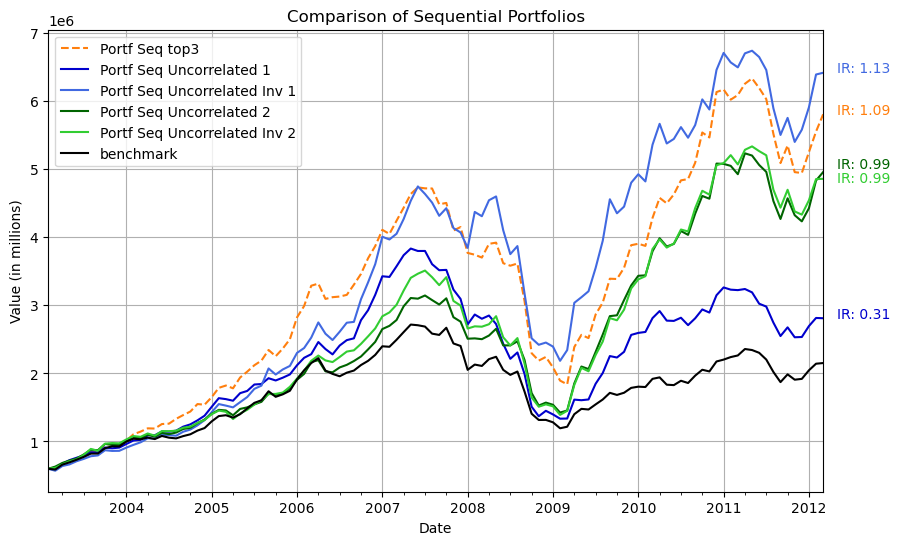

```python
plt.figure(figsize =(10, 6))

portf_seq_top3.loc['value'].plot(label = 'Portf Seq top3', linestyle = 'dashed', color='C1')
portf_uncorr_seq1.loc['value'].plot(label = 'Portf Seq Uncorrelated 1', color='mediumblue')
portf_uncorr_seq_inv1.loc['value'].plot(label = 'Portf Seq Uncorrelated Inv 1', color='royalblue')
portf_uncorr_seq2.loc['value'].plot(label = 'Portf Seq Uncorrelated 2', color='darkgreen')
portf_uncorr_seq_inv2.loc['value'].plot(label = 'Portf Seq Uncorrelated Inv 2', color='limegreen')
benchmark.loc['value'].plot(label = "benchmark", color='black')
plt.grid()
plt.title("Comparison of Sequential Portfolios")
plt.ylabel("Value (in millions)")
plt.text(508, portf_seq_top3.loc['value'][-1], 'IR: ' + str(round(IR(portf_seq_top3),2)), color='C1')
plt.text(508, portf_uncorr_seq1.loc['value'][-1], 'IR: ' + str(round(IR(portf_uncorr_seq1),2)), color='mediumblue')
plt.text(508, portf_uncorr_seq_inv1.loc['value'][-1], 'IR: ' + str(round(IR(portf_uncorr_seq_inv1),2)), color='royalblue')
plt.text(508, portf_uncorr_seq2.loc['value'][-1] + 50000, 'IR: ' + str(round(IR(portf_uncorr_seq2),2)), color='darkgreen')
plt.text(508, portf_uncorr_seq_inv2.loc['value'][-1] - 50000, 'IR: ' + str(round(IR(portf_uncorr_seq_inv2),2)), color='limegreen')
plt.legend()
plt.show()
```

The sequential portfolio built using the "uncorrelated" factors with strategy 1 achieves lower performances and a low Information Ratio (0.31). The opposite happens for the inverted version, that outperforms the standard sequential screening model, achieving an Information Ratio of 1.13.  
For what regards the second strategy, both portfolios achieve very good performance 0.99, buth none of them beat the original sequential portfolio.

[figure not shown]

```python
plt.figure(figsize =(10, 6))

portf_sim_top6.loc['value'].plot(label = "Simultaneous Top6", color = 'C3', linestyle = 'dashed')
portf_uncorr_sim1.loc['value'].plot(label = "Simultaneous Uncorrelated 1", color = 'mediumblue')
portf_uncorr_sim2.loc['value'].plot(label = "Simultaneous Uncorrelated 2", color = 'darkgreen')
benchmark.loc['value'].plot(label = "benchmark", color='black')
plt.title("Comparison of Sequential Portfolios")
plt.ylabel("Value (in millions)")
plt.grid()
plt.text(508, portf_sim_top6.loc['value'][-1], 'IR: ' + str(round(IR(portf_sim_top6),2)), color='C3')
plt.text(508, portf_uncorr_sim1.loc['value'][-1], 'IR: ' + str(round(IR(portf_uncorr_sim1),2)), color='mediumblue')
plt.text(508, portf_uncorr_sim2.loc['value'][-1], 'IR: ' + str(round(IR(portf_uncorr_sim2),2)), color='darkgreen')
plt.legend()
plt.show()
```

The uncorrelated strategy 1 does not show to be as effective as for the sequential portfolios. This probably is due to an extreme correlation between the univariate portfolios.  
Neither the uncorrelated strategy 2 does not achieve as high information ratio as in the sequential portfolios. Nonetheless, the IR is pretty good (0.76).

# Weighted Portfolio

Until now, all the tried strategy were equally weighted. We now try to change the simultaneous function in order to build new portfolios with a weighted strategy.  
To weight the assets inside our portfolios we are going to use the volatility of the assets themselves. More specifically, we weighted by the inverse of volatility. This was done to produce less risky portfolios, since less volatile assets are going to receive a greater weight.

```python
def weightPortfolio(data, holding, weight, wealth = 600000, n_stocks=15):
    # Initialize worst list
    worst = []
    for factor in range(len(data)):
        worst.append(diz_factors[data[factor]])
    # Initiate dataset
    sub = pd.DataFrame(columns=time, index = stocks)
    # Set i = 1, we want to start at month 2, so that we can use the information of the factor at month 1
    i=1
    # Remove the transaction cost in the first iteration of wealth
    wealth = wealth * 0.998
    # Initialize weight dataset
    weight = get_factor(weight).replace(0, np.nan)**(-1)
    # Loop through i. i is going to represent the month in which the selected stocks are modified based on the factor
    while i < len(time):
        # If we are not in the first month, we have to compute the portfolio value in the new month before reallocation
        if i != 1:
            portfT = sub.iloc[:,i-1] * price_mul.iloc[:,i]
            # Overwrite the wealth as the portfolio total value
            wealth = portfT.sum()
        # Create a copy of the factors
        fac = []
        for el in range(len(data)):
            fac.append(get_factor(data[el]).loc[price_mul.iloc[:,i].notnull(),:])
        # Select stocks based on factor
        sub_factor = pd.DataFrame(columns=range(len(data)+1), index = fac[0].index)
        for el in range(len(data)):
            new_col = scale(fac[el].iloc[:,i-1])
            if worst[el]:
                new_col = new_col * -1
            sub_factor[el] = new_col
        sub_factor.iloc[:,-1] = sub_factor.mean(axis=1)
        sel_stocks = sub_factor.sort_values(sub_factor.columns[-1], ascending=False).index[:n_stocks]
        # Get sum of the weights
        tot_weight = weight.loc[sel_stocks, weight.columns[i-1]].sum()
        sub_weight = weight.loc[sel_stocks, weight.columns[i-1]] / tot_weight
        # Allocate wealth equally through the selected stocks
        sub.loc[sel_stocks, sub.columns[i]] = wealth * sub_weight
        # If we are not in the first month, than we have to compute the transaction costs
        if i != 1:
            # We compute the transaction costs based on the difference between the portfolio before and after reallocation
            trans_cost = abs(sub.iloc[:,i] - portfT).sum() * 0.002
            # Remove the transaction cost from total wealth
            wealth = wealth - trans_cost
            # Overwrite allocation of wealth equally through the selected stocks
            sub.loc[sel_stocks, sub.columns[i]] = wealth * sub_weight
        # J is going to loop through the months in which there is no reallocation
        for j in range(1,holding):
            # Break the j loop if the months are finished
            if i + j > len(time)-1:
                break
            # Compute the value of all the stocks at time t as their value at time t-1 times theprice multiplicator at time t
            sub.iloc[:,i+j] = sub.iloc[:,i+j-1] * price_mul.iloc[:,i+j]
        # Increment i by the holding period before next iteration
        i += holding
    # Since we started from i=1, the first element of the subset is going to be 0, so we are going to remove it
    # Build output dataframe
    portf = pd.DataFrame(columns=time[1:])
    # Insert value information
    portf.loc['value'] = sub.sum()[1:]
    # Insert return information
    portf.loc['returns'] = (portf.loc['value'].astype('float') - portf.loc['value'].shift(1).astype('float'))/portf.loc['value'].shift(1).astype('float')
    portf.loc['cum_returns'] = (portf.loc['value'].astype('float') - portf.loc['value'][0])/portf.loc['value'][0]
    portf.loc['log_returns'] = np.log(portf.loc['value'].astype('float')) - np.log(portf.loc['value'].shift(1).astype('float'))
    return portf
```

```python
portf_weight_180 = weightPortfolio(['PE_RATIO','CURRENT_EV_TO_12M_SALES','FIVE_YEAR_AVG_EV_TO_T12_EBITDA', 'CURRENT_EV_TO_T12M_EBITDA', 'PX_TO_BOOK_RATIO', 'NORMALIZED_ACCRUALS_CF_METHOD'], 12, 'VOLATILITY_180D')
portf_weight_90 = weightPortfolio(['PE_RATIO','CURRENT_EV_TO_12M_SALES','FIVE_YEAR_AVG_EV_TO_T12_EBITDA', 'CURRENT_EV_TO_T12M_EBITDA', 'PX_TO_BOOK_RATIO', 'NORMALIZED_ACCRUALS_CF_METHOD'], 12, 'VOLATILITY_90D')
portf_weight_30 = weightPortfolio(['PE_RATIO','CURRENT_EV_TO_12M_SALES','FIVE_YEAR_AVG_EV_TO_T12_EBITDA', 'CURRENT_EV_TO_T12M_EBITDA', 'PX_TO_BOOK_RATIO', 'NORMALIZED_ACCRUALS_CF_METHOD'], 12, 'VOLATILITY_30D')
```

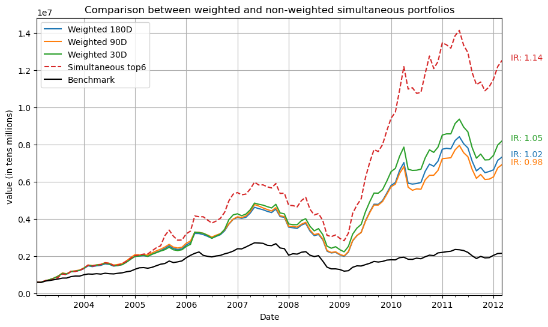

```python
plt.figure(figsize =(10, 6))

portf_weight_180.loc['value'].plot(label = "Weighted 180D", color = 'C0')
portf_weight_90.loc['value'].plot(label = "Weighted 90D", color = 'C1')
portf_weight_30.loc['value'].plot(label = "Weighted 30D", color = 'C2')
portf_sim_top6.loc['value'].plot(label = "Simultaneous top6", color = 'C3', linestyle = 'dashed')
benchmark.loc['value'].plot(label = "Benchmark", color='black')
plt.title("Comparison between weighted and non-weighted simultaneous portfolios")
plt.text(508, portf_weight_180.loc['value'][-1], 'IR: ' + str(round(IR(portf_weight_180),2)), color='C0')
plt.text(508, portf_weight_90.loc['value'][-1], 'IR: ' + str(round(IR(portf_weight_90),2)), color='C1')
plt.text(508, portf_weight_30.loc['value'][-1], 'IR: ' + str(round(IR(portf_weight_30),2)), color='C2')
plt.text(508, portf_sim_top6.loc['value'][-1], 'IR: ' + str(round(IR(portf_sim_top6),2)), color='C3')
plt.grid()
plt.legend()
plt.ylabel("value (in tens millions)")
plt.show()
```

```python
# Initialize an empty rank dataframe
rank_weight = pd.DataFrame(columns = ['Information', 'Sharpe', 'Sortino'],
                    index = ['portf_weight_180', 'portf_weight_90', 'portf_weight_30', 'portf_sim_top6'])
```

```python
# For each portfolio insert in the dataframe its resulting metrics
port_list = [portf_weight_180, portf_weight_90, portf_weight_30, portf_sim_top6]
for i in range(4):
    rank_weight.iloc[i]['Information'] = IR(port_list[i])
    rank_weight.iloc[i]['Sharpe'] = Sharpe(port_list[i])
    rank_weight.iloc[i]['Sortino'] = Sortino(port_list[i])
```

```python
rank_weight
```

|  | Information | Sharpe | Sortino |
| --- | --- | --- | --- |
| portf_weight_180 | 1.022047 | 0.705464 | 0.969694 |
| portf_weight_90 | 0.981541 | 0.698841 | 0.948778 |
| portf_weight_30 | 1.053439 | 0.71037 | 1.028956 |
| portf_sim_top6 | 1.138483 | 0.696275 | 1.12746 |

As expected, the weighted portfolio are less risky. Because of that, they achieve less returns, but the metrics remain very good.

# Prophet Portfolio

This section propose an AI strategy to build new portfolios. We used a rolling version of the Prophet model (developed by Meta) to forecast future returns for each asset, based on past-year factors. The predicted returns were then used as a factor for an univariate screening strategy. In other words, each year the portfolio is built using the stock with the best predicted total return at the end of next year.

```python
from prophet import Prophet
```

```python
sel_factors = list(rank.index[0:5])
```

```python
wealth = 600000
skip_count = 0
i = 12
sub = pd.DataFrame(columns=time, index = stocks)
while i < len(time) - 12:
    # If we are not in the first month, we have to compute the portfolio value in the new month before reallocation
    if i != 12:
        portfT = sub.iloc[:,i-1] * price_mul.iloc[:,i]
        # Overwrite the wealth as the portfolio total value
        wealth = portfT.sum()
    stock_rank = {}
    # For each stock, build the prophet prediction
    for stock in stocks:
        # Get the stock data
        ind = df.index.get_loc(stock + ' Equity')
        df_stock = df.iloc[range(ind + 2, ind + 42)].transpose()
        # Change the data shape and names in order to be used as input by Prophet
        df_stock['ds'] = df.loc['Date'].iloc[0]
        df_stock.index = range(len(df_stock))
        df_stock = df_stock.rename(columns = {'PX_LAST':'y'})
        # If the stock has no information about the value of the factors that are going to be used as explanatory variable, skip this stock
        if df_stock[sel_factors].isnull().sum().sum() != 0:
            skip_count += 1
            continue
        # The train dataset utilizes all the factor values available until before the past year
        train = df_stock[:i]
        # + the price in the subsequent year of the factors (until past year)
        train['y'] =  df_stock.loc[range(12,i+12),'y'].values.tolist()
        # The test dataset utilizes all the factor values available in the past year
        test = pd.DataFrame(df_stock[i:i+12])
        m = Prophet()
        # This loop add every selected factor as explanatory variable in the model
        for factor in sel_factors:
            m.add_regressor(factor)
        # Train the data
        m.fit(train)
        # Build the prediction
        prediction = m.predict(test)
        # Compute the predicted return
        stock_rank[stock] = (prediction.iloc[-1]['yhat'] - train.iloc[-1]['y']) / train.iloc[-1]['y']
    # The selected stocks are going to be those with the best predicted return
    sel_stocks = pd.DataFrame(sorted(stock_rank.items(), key=lambda x:x[1], reverse=True)[:15])[0]
    # Allocate wealth equally through the selected stocks
    sub.loc[sel_stocks, sub.columns[i]] = wealth/len(sel_stocks)
    # If we are not in the first month, than we have to compute the transaction costs
    if i != 12:
        # We compute the transaction costs based on the difference between the portfolio before and after reallocation
        trans_cost = abs(sub.iloc[:,i] - portfT).sum() * 0.002
        # Remove the transaction cost from total wealth
        wealth = wealth - trans_cost
        # Overwrite allocation of wealth equally through the selected stocks
        sub.loc[sel_stocks, sub.columns[i]] = wealth/len(sel_stocks)
    # J is going to loop through the months in which there is no reallocation
    for j in range(1,12):
        # Break the j loop if the months are finished
        if i + j > len(time)-1:
            break
        # Compute the value of all the stocks at time t as their value at time t-1 times theprice multiplicator at time t
        sub.iloc[:,i+j] = sub.iloc[:,i+j-1] * price_mul.iloc[:,i+j]
    # Increment i by the holding period before next iteration
    i += 12
portf = pd.DataFrame(columns=time[12:])
# Insert value information
portf.loc['value'] = sub.sum()
# Insert return information
portf.loc['returns'] = (portf.loc['value'].astype('float') - portf.loc['value'].shift(1).astype('float'))/portf.loc['value'].shift(1).astype('float')
portf.loc['cum_returns'] = (portf.loc['value'].astype('float') - portf.loc['value'][0])/portf.loc['value'][0]
portf.loc['log_returns'] = np.log(portf.loc['value'].astype('float')) - np.log(portf.loc['value'].shift(1).astype('float'))
```

```python
nan_factors = []
for factor_name in sel_factors:
    factor = get_factor(factor_name)
    print(factor_name, factor.isnull().any(axis=1).sum())
```

```
CUR_MKT_CAP 14
PE_RATIO 453
CURRENT_EV_TO_12M_SALES 415
FIVE_YEAR_AVG_EV_TO_T12_EBITDA 526
CURRENT_EV_TO_T12M_EBITDA 498
```

While trying this strategy, we found that many stocks were not considered in the prediction due to the presence of nan values in the factors.

```python
prop_portf = portf
```

```python
# Build a benchmark that start at the same month
sub = pd.DataFrame(columns=time, index = stocks)
i=13
# Remove the transaction cost in the first iteration of wealth
wealth = 600000 * 0.998
# To calculate the benchmark we select only the stocks that have no null information in the price df
sel_stocks = price[~price.isnull().any(axis=1)].index
# Allocate wealth equally through the selected stocks
sub.loc[sel_stocks, sub.columns[12]] = wealth/len(sel_stocks)
# Calculate the value of the portfolio at each iteration of time
while i < len(time):
    sub.iloc[:,i] = sub.iloc[:,i-1] * price_mul.iloc[:,i]
    i += 1
# Build output dataframe
bench = pd.DataFrame(columns=time[12:])
# Insert value information
bench.loc['value'] = sub.sum()[1:]
# Insert return information
bench.loc['returns'] = (bench.loc['value'].astype('float') - bench.loc['value'].shift(1).astype('float'))/bench.loc['value'].shift(1).astype('float')
bench.loc['cum_returns'] = (bench.loc['value'].astype('float') - bench.loc['value'][0])/bench.loc['value'][0]
bench.loc['log_returns'] = np.log(bench.loc['value'].astype('float')) - np.log(bench.loc['value'].shift(1).astype('float'))
```

```python
bench_mom = bench
```

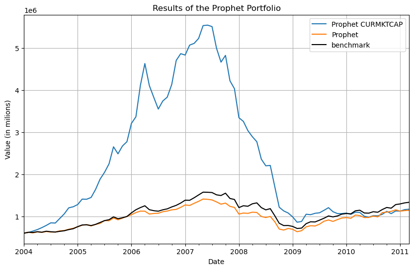

```python
plt.figure(figsize =(10, 6))

prop_portf_CURMKTCAP.loc['value'][:-12].plot(label = "Prophet CURMKTCAP", color = 'C0')
prop_portf.loc['value'][:-12].plot(label = "Prophet", color = 'C1')
bench_mom.loc['value'][:-12].plot(label = 'benchmark', color = 'black')
plt.title("Results of the Prophet Portfolio")
plt.ylabel("Value (in milions)")
plt.grid()
plt.legend()
plt.show()
```

The resulting performance are bad compared to the other portfolios built with the sequential and simultaneous strategies. This could be due to the fact that the model was not tuned and predicts badly the returns of the each stock in the next year. With a better tuning and data with less empty values, the new factor could be more robust and may provide better results.

# Momentum Portfolio

The last strategy we developed uses momentum to select stocks at every holding period (3 months). The momentum is built using a cross-sectional approach, with 6-1 formation period.

```python
wealth = 600000
i = 6
wealth = wealth * 0.998
sub = pd.DataFrame(columns=time, index = stocks)
while i < len(time):
    # If we are not in the first month, we have to compute the portfolio value in the new month before reallocation
    if i != 6:
        portfT = sub.iloc[:,i-1] * price_mul.iloc[:,i]
        # Overwrite the wealth as the portfolio total value
        wealth = portfT.sum()
    momentum_diz = {}
    # For each stock, we compute its momentum
    for stock in stocks:
        # The momentum is computed as [price(time-6) - price(time-2)] / price(time-6)
        momentum = (price.loc[stock,price.columns[i-2]] - price.loc[stock,price.columns[i-6]]) / price.loc[stock,price.columns[i-6]]
        # We save the momentum in a dictionary
        momentum_diz[stock] = momentum
    # We select the 15 stocks with the best momentum
    sel_stocks = pd.DataFrame(sorted(momentum_diz.items(), key=lambda x:x[1], reverse=True)[:15])[0]
    # Allocate wealth equally through the selected stocks
    sub.loc[sel_stocks, sub.columns[i]] = wealth/len(sel_stocks)
    # If we are not in the first month, than we have to compute the transaction costs
    if i != 6:
        # We compute the transaction costs based on the difference between the portfolio before and after reallocation
        trans_cost = abs(sub.iloc[:,i] - portfT).sum() * 0.002
        # Remove the transaction cost from total wealth
        wealth = wealth - trans_cost
        # Overwrite allocation of wealth equally through the selected stocks
        sub.loc[sel_stocks, sub.columns[i]] = wealth/len(sel_stocks)
    # J is going to loop through the months in which there is no reallocation
    for j in range(1,3):
        # Break the j loop if the months are finished
        if i + j > len(time)-1:
            break
        # Compute the value of all the stocks at time t as their value at time t-1 times theprice multiplicator at time t
        sub.iloc[:,i+j] = sub.iloc[:,i+j-1] * price_mul.iloc[:,i+j]
    # Increment i by the holding period before next iteration
    i += 3
portf = pd.DataFrame(columns=time[6:])
# Insert value information
portf.loc['value'] = sub.sum()
# Insert return information
portf.loc['returns'] = (portf.loc['value'].astype('float') - portf.loc['value'].shift(1).astype('float'))/portf.loc['value'].shift(1).astype('float')
portf.loc['cum_returns'] = (portf.loc['value'].astype('float') - portf.loc['value'][0])/portf.loc['value'][0]
portf.loc['log_returns'] = np.log(portf.loc['value'].astype('float')) - np.log(portf.loc['value'].shift(1).astype('float'))
```

```python
momentum_portf = portf
```

Since our momentum portfolio starts at time 7 (since it has to use the momentum computed on the past 6 months), we compare it to a benchmark that starts at the same time.

```python
# Build a benchmark that start at the same month
sub = pd.DataFrame(columns=time, index = stocks)
i=7
# Remove the transaction cost in the first iteration of wealth
wealth = 600000 * 0.998
# To calculate the benchmark we select only the stocks that have no null information in the price df
sel_stocks = price[~price.isnull().any(axis=1)].index
# Allocate wealth equally through the selected stocks
sub.loc[sel_stocks, sub.columns[6]] = wealth/len(sel_stocks)
# Calculate the value of the portfolio at each iteration of time
while i < len(time):
    sub.iloc[:,i] = sub.iloc[:,i-1] * price_mul.iloc[:,i]
    i += 1
# Build output dataframe
bench = pd.DataFrame(columns=time[6:])
# Insert value information
bench.loc['value'] = sub.sum()[1:]
# Insert return information
bench.loc['returns'] = (bench.loc['value'].astype('float') - bench.loc['value'].shift(1).astype('float'))/bench.loc['value'].shift(1).astype('float')
bench.loc['cum_returns'] = (bench.loc['value'].astype('float') - bench.loc['value'][0])/bench.loc['value'][0]
bench.loc['log_returns'] = np.log(bench.loc['value'].astype('float')) - np.log(bench.loc['value'].shift(1).astype('float'))
```

```python
bench_mom = bench
```

[figure not shown]

```python
plt.figure(figsize =(10, 6))

momentum_portf.loc['value'].plot(label = 'momentum', color='C1')
bench_mom.loc['value'].plot(label = 'benchmark', color='black')

plt.text(508, momentum_portf.loc['value'][-1], 'IR: ' + str(round(IR(momentum_portf),2)), color='C1')

plt.grid()
plt.title('Comparison of Momentum Portfolio with Benchmark')
plt.ylabel('value (in tens of milions)')
plt.legend()
plt.show()
```

The portfolio built using the momentum strategy achieves a good Information Ratio (0.98) but not as high as other approaches.